# RestoreDART sample size and filtering checks

BEM

September 2026

## Notes

- This document holds the **per-objective detail**: how much data backs each objective x cover response, what the three sample-size filters removed, and what that objective’s own results look like. It is written for deciding what the data can support, not for reporting conclusions - the collaborator-facing results are in `2_make_DART_results.Rmd`, which carries the cross-objective direction checks and every table compiled across objectives. The bulky per-ecoregion reference graphs are in `2_raw_result_graphs.Rmd`.

Each section covers one objective x cover response, in five parts:

1. **Sample sizes and scope** - pixel counts per treatment x ecoregion cell and, post-filter, per treatment and per ecoregion; what each of the three filters removed; how much of this objective’s data is shared with other objectives.
2. **Pixel and polygon counts, post-filtering** - the three count histograms.
3. **Significant DART effects, by covariate** - the overall significance rate, then the same rate by fine objective, treatment and ecoregion.
4. **Significant DART effects, through time** - significance by year since treatment, effect magnitude and peak years, and how per-polygon peak years distribute across treatments and ecoregions.
5. **Overall results and interpretation** - that objective’s filtering statistics in one row, then the hand-written interpretation. The prose is the only part of a section that is not generated.

A final section, **Overall results and interpretation, all objectives**, closes the document: the filtering statistics for all five objectives in one table, and the five interpretations together. It is emitted from the same per-objective sources as the sections above rather than restating them, so editing a bullet in its own section updates both places.

### cover: AFG , objective: decrease afg

#### Sample sizes and scope

How much data backs this objective x cover response, how much of it the three sample-size filters removed, and how much of it is shared with other objectives. Everything here is descriptive: no treatment effect is reported in this subsection. Pixel counts are shown per treatment x ecoregion cell, which is the unit the first filter works on, and then again per treatment and per ecoregion *after* filtering - the pre-filter totals by treatment and by ecoregion were dropped as unhelpful, since nothing downstream is built on them.

##### Pixel counts for each treatment × ecoregion combination (`'tx_coarse'` x `'us_l4name'`)

Each level of (treatment x ecoregion) is filtered here for low sample size (300 pixels).

|  | Crystalline Mid-Elevation Forests | Dissected High Lava Plateau | Eastern Mojave Low Ranges and Arid Footslopes | Escarpments | Foothill Shrublands and Low Mountains | Malad and Cache Valleys | Mid-Elevation Uinta Mountains | Monticello-Cortez Uplands | Mountain Valleys | Northern Uinta Basin Slopes | Rolling Sagebrush Steppe | Sagebrush Basins and Slopes | Semiarid Benchlands and Canyonlands | Semiarid Foothills | Semiarid Hills and Low Mountains | Shadscale-Dominated Saline Basins | Uinta Basin Floor | Woodland- and Shrub-Covered Low Mountains |
| --- | --- | --- | --- | --- | --- | --- | --- | --- | --- | --- | --- | --- | --- | --- | --- | --- | --- | --- |
| prescribed burn;seeding;soil disturbance | 0 | 0 | 0 | 0 | 120 | 0 | 0 | 0 | 0 | 0 | 0 | 0 | 0 | 0 | 0 | 0 | 0 | 0 |
| prescribed burn;seeding;soil disturbance;vegetation removal | 0 | 0 | 0 | 0 | 0 | 0 | 0 | 0 | 0 | 0 | 0 | 0 | 272 | 0 | 0 | 0 | 0 | 0 |
| seeding | 0 | 2448 | 0 | 1564 | 900 | 0 | 0 | 666 | 36 | 1501 | 0 | 6841 | 5576 | 78 | 854 | 57 | 0 | 7383 |
| seeding;soil disturbance | 0 | 0 | 0 | 0 | 0 | 0 | 0 | 0 | 152 | 0 | 0 | 6533 | 936 | 1677 | 0 | 11086 | 0 | 2120 |
| seeding;soil disturbance;vegetation removal | 0 | 0 | 0 | 0 | 0 | 0 | 0 | 0 | 505 | 0 | 874 | 1241 | 1104 | 616 | 0 | 3750 | 1008 | 2147 |
| seeding;vegetation removal | 0 | 380 | 0 | 1373 | 0 | 81 | 84 | 0 | 119 | 0 | 231 | 711 | 33 | 469 | 350 | 384 | 132 | 2419 |
| soil disturbance | 0 | 0 | 65 | 0 | 0 | 0 | 0 | 0 | 55 | 0 | 0 | 0 | 0 | 48 | 0 | 27 | 0 | 0 |
| soil disturbance;vegetation removal | 0 | 0 | 0 | 0 | 0 | 0 | 0 | 0 | 0 | 0 | 0 | 192 | 455 | 0 | 0 | 0 | 0 | 522 |
| vegetation removal | 132 | 0 | 0 | 0 | 0 | 0 | 0 | 0 | 1196 | 162 | 0 | 11066 | 435 | 2095 | 0 | 0 | 18 | 1078 |

|  | Crystalline Mid-Elevation Forests | Eastern Mojave Low Ranges and Arid Footslopes | Foothill Shrublands and Low Mountains | Malad and Cache Valleys | Mid-Elevation Uinta Mountains | Mountain Valleys | Northern Uinta Basin Slopes | Rolling Sagebrush Steppe | Sagebrush Basins and Slopes | Semiarid Benchlands and Canyonlands | Semiarid Foothills | Shadscale-Dominated Saline Basins | Uinta Basin Floor |
| --- | --- | --- | --- | --- | --- | --- | --- | --- | --- | --- | --- | --- | --- |
| prescribed burn;seeding;soil disturbance |  |  | 120 |  |  |  |  |  |  |  |  |  |  |
| prescribed burn;seeding;soil disturbance;vegetation removal |  |  |  |  |  |  |  |  |  | 272 |  |  |  |
| seeding |  |  |  |  |  | 36 |  |  |  |  | 78 | 57 |  |
| seeding;soil disturbance |  |  |  |  |  | 152 |  |  |  |  |  |  |  |
| seeding;vegetation removal |  |  |  | 81 | 84 | 119 |  | 231 |  | 33 |  |  | 132 |
| soil disturbance |  | 65 |  |  |  | 55 |  |  |  |  | 48 | 27 |  |
| soil disturbance;vegetation removal |  |  |  |  |  |  |  |  | 192 |  |  |  |  |
| vegetation removal | 132 |  |  |  |  |  | 162 |  |  |  |  |  | 18 |

**Table.** The first table is the full pixel count for every treatment (rows) x ecoregion (columns) combination; the second keeps only the cells that are non-zero but below the 300-pixel threshold, i.e. the combinations that are present but too sparse to analyse. Empty cells in the second table are combinations that are either absent or above the threshold.

| Treatment | Ecoregion |
| --- | --- |
| vegetation removal | Crystalline Mid-Elevation Forests |
| soil disturbance | Eastern Mojave Low Ranges and Arid Footslopes |
| prescribed burn;seeding;soil disturbance | Foothill Shrublands and Low Mountains |
| seeding;vegetation removal | Malad and Cache Valleys |
| seeding;vegetation removal | Mid-Elevation Uinta Mountains |
| seeding | Mountain Valleys |
| seeding;soil disturbance | Mountain Valleys |
| seeding;vegetation removal | Mountain Valleys |
| soil disturbance | Mountain Valleys |
| vegetation removal | Northern Uinta Basin Slopes |
| seeding;vegetation removal | Rolling Sagebrush Steppe |
| soil disturbance;vegetation removal | Sagebrush Basins and Slopes |
| prescribed burn;seeding;soil disturbance;vegetation removal | Semiarid Benchlands and Canyonlands |
| seeding;vegetation removal | Semiarid Benchlands and Canyonlands |
| seeding | Semiarid Foothills |
| soil disturbance | Semiarid Foothills |
| seeding | Shadscale-Dominated Saline Basins |
| soil disturbance | Shadscale-Dominated Saline Basins |
| seeding;vegetation removal | Uinta Basin Floor |
| vegetation removal | Uinta Basin Floor |

**Table.** 20 treatment x ecoregion combinations fall below the 300-pixel threshold, representing 2.42% of the total sample size for this objective x cover response. Each row is one combination that will be dropped below.

**Are these sparse combinations especially significant (or non-significant)?**

| Treatment | Ecoregion | Significant Pixels | Total Pixels | % Significant Pixels |
| --- | --- | --- | --- | --- |
| prescribed burn;seeding;soil disturbance | Foothill Shrublands and Low Mountains | 21 | 120 | 17.50 |
| prescribed burn;seeding;soil disturbance;vegetation removal | Semiarid Benchlands and Canyonlands | 54 | 272 | 19.85 |
| seeding | Mountain Valleys | 9 | 36 | 25.00 |
| seeding | Semiarid Foothills | 51 | 78 | 65.38 |
| seeding | Shadscale-Dominated Saline Basins | 16 | 57 | 28.07 |
| seeding;soil disturbance | Mountain Valleys | 30 | 152 | 19.74 |
| seeding;vegetation removal | Malad and Cache Valleys | 0 | 81 | 0.00 |
| seeding;vegetation removal | Mid-Elevation Uinta Mountains | 3 | 84 | 3.57 |
| seeding;vegetation removal | Mountain Valleys | 13 | 119 | 10.92 |
| seeding;vegetation removal | Rolling Sagebrush Steppe | 0 | 231 | 0.00 |
| seeding;vegetation removal | Semiarid Benchlands and Canyonlands | 0 | 33 | 0.00 |
| seeding;vegetation removal | Uinta Basin Floor | 0 | 132 | 0.00 |
| soil disturbance | Eastern Mojave Low Ranges and Arid Footslopes | 30 | 65 | 46.15 |
| soil disturbance | Mountain Valleys | 35 | 55 | 63.64 |
| soil disturbance | Semiarid Foothills | 32 | 48 | 66.67 |
| soil disturbance | Shadscale-Dominated Saline Basins | 0 | 27 | 0.00 |
| soil disturbance;vegetation removal | Sagebrush Basins and Slopes | 8 | 192 | 4.17 |
| vegetation removal | Crystalline Mid-Elevation Forests | 47 | 132 | 35.61 |
| vegetation removal | Northern Uinta Basin Slopes | 70 | 162 | 43.21 |
| vegetation removal | Uinta Basin Floor | 1 | 18 | 5.56 |

**Table.** Significance rate within the sparse combinations only: one row per dropped treatment x ecoregion combination, giving its significant pixel count, its total pixel count, and the resulting percentage. Compare against the overall rate reported further down to see whether the dropped cells were unusual.

##### Results after dropping (treatment x ecoregion)

The pixel cutoff for each (treatment × ecoregion) combination was 300.

Three filters have now been applied to this objective x cover response, in this order, and the percentage below is the combined cost of all three:

1. **Sparse (treatment x ecoregion) cells** - the 20 combinations listed above, below 300 pixels each.
2. **Depopulated treatment or ecoregion levels** - on, at the same 300-pixel threshold: 0 treatment and 0 ecoregion level(s) removed. This catches a level thinned across many surviving cells, which the cell filter cannot see.
3. **Late-year truncation** - year 27 was the first below 10 significant pixels, so it and the 1 year(s) after it were dropped; the series now ends at year 26.

Total data lost across all three: **2.53%**. Treatment levels absent from the post-filter data: `soil disturbance`, `prescribed burn;seeding;soil disturbance`, `prescribed burn;seeding;soil disturbance;vegetation removal`. Ecoregion levels absent: `Eastern Mojave Low Ranges and Arid Footslopes`, `Malad and Cache Valleys`, `Crystalline Mid-Elevation Forests`, `Mid-Elevation Uinta Mountains`. (These are levels gone for *any* reason - a level that only ever appeared in sparse cells disappears without the depopulation filter being involved.)

The post-filter totals below are the check that the three filters together have not left some treatment or ecoregion analysable in name only.

| Treatment | Pixel Count (post-filter) |
| --- | --- |
| seeding | 27645 |
| seeding;soil disturbance | 22352 |
| seeding;soil disturbance;vegetation removal | 11245 |
| seeding;vegetation removal | 6086 |
| soil disturbance;vegetation removal | 977 |
| vegetation removal | 15870 |

| Ecoregion | Pixel Count (post-filter) |
| --- | --- |
| Dissected High Lava Plateau | 2828 |
| Escarpments | 2937 |
| Foothill Shrublands and Low Mountains | 900 |
| Monticello-Cortez Uplands | 666 |
| Mountain Valleys | 1701 |
| Northern Uinta Basin Slopes | 1501 |
| Rolling Sagebrush Steppe | 874 |
| Sagebrush Basins and Slopes | 26304 |
| Semiarid Benchlands and Canyonlands | 8506 |
| Semiarid Foothills | 4857 |
| Semiarid Hills and Low Mountains | 1204 |
| Shadscale-Dominated Saline Basins | 15220 |
| Uinta Basin Floor | 1008 |
| Woodland- and Shrub-Covered Low Mountains | 15669 |

**Tables.** Post-filter pixel totals, by treatment and by ecoregion, after the sparse combinations above were dropped. The smallest surviving treatment total is 977 pixels and the smallest surviving ecoregion total is 666 pixels, against a combination-level threshold of 300.

##### How often does this objective overlap with other objectives?

| Objective | Cover | Co-occurring Objective | Pixel Count | % of Total Pixels |
| --- | --- | --- | --- | --- |
| decrease_afg | AFG | none | 4781 | 5.68 |
| decrease_afg | AFG | increase_pfg | 66639 | 79.17 |
| decrease_afg | AFG | increase_shr | 45214 | 53.71 |
| decrease_afg | AFG | decrease_tre | 10900 | 12.95 |
| decrease_afg | AFG | decrease_shr | 4101 | 4.87 |

**Table.** Among pixels assigned to decrease_afg, how often each *other* objective was also assigned to that same pixel. The first row (`none`) is the pixels that carried no other objective. Percentages are shares of this objective’s own (post-filter) pixel total, so they sum to more than 100% wherever pixels carry more than two objectives.

#### Pixel and polygon counts, post-filtering

Pixel counts per polygon, excluding zeros, *i.e.* no pixels present for that `'tx_coarse'` x `'us_l4name'` combination):

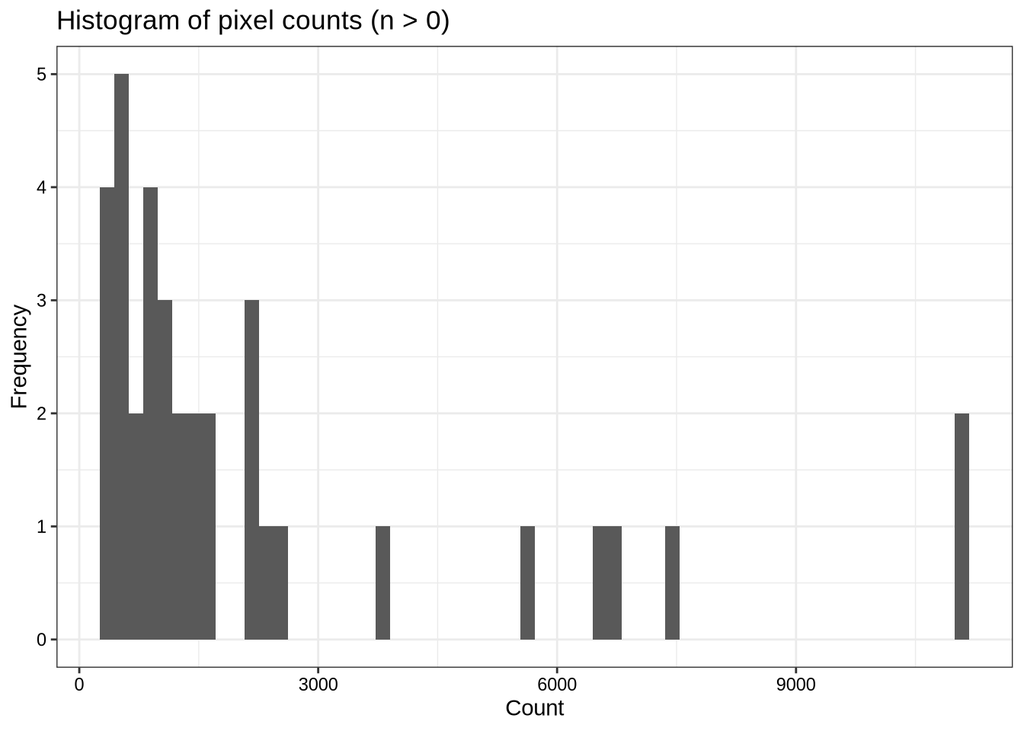

**Figure.** X axis: the pixel count of a single treatment x ecoregion cell. Y axis: how many such cells fall in that count bin (frequency). Cells with zero pixels are excluded, so the distribution describes only combinations that exist in the data. No groupings, colours or facets.

Polygon count table, plotted as histogram, zeroes excluded:

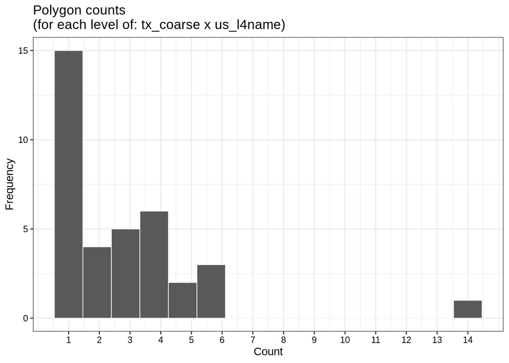

**Figure.** X axis: the number of distinct polygons in a single treatment x ecoregion cell, with one break per integer. Y axis: how many cells have that polygon count (frequency). Zero-polygon cells are excluded. No groupings, colours or facets.

Polygon count table: for each year since treatment, how many distinct polygons contribute at least one pixel that year.

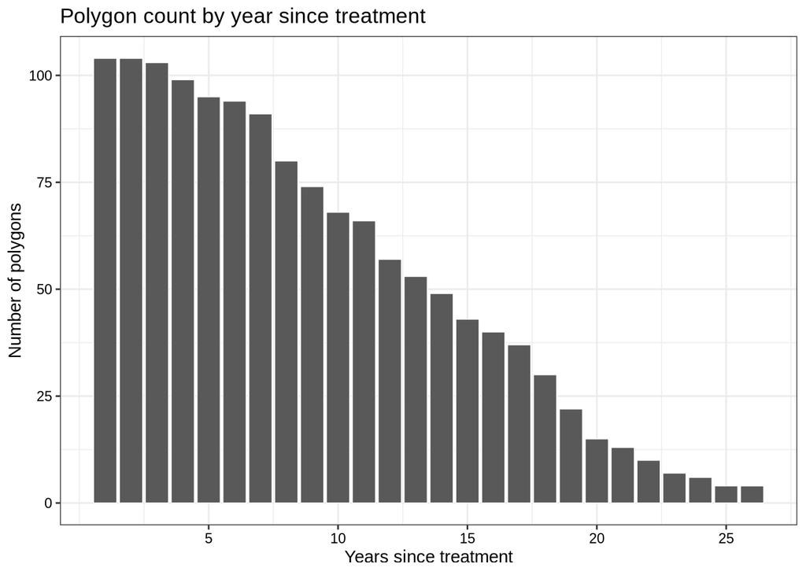

**Figure.** X axis: years since treatment, labelled every 5 years. Y axis: the number of distinct polygons contributing at least one pixel in that year - i.e. how many independent spatial replicates back that year, which is a different quantity from the year’s pixel count. No groupings, colours or facets.

#### Significant DART effects, by covariate

How often a significant effect occurred, first as one rate for the whole objective and then broken apart by fine objective, by treatment and by ecoregion. All of it is cross-sectional - the time dimension is the next subsection - and all of it reports the *intended* effect, since every level on these axes shares this objective’s management goal.

##### How many pixels have a significant DART result?

DART results are considered significant if the confidence intervals for each DART estimate do not include zero.

| Objective | Cover | Total Pixels | % Significant | % Significant Positive | % Significant Negative |
| --- | --- | --- | --- | --- | --- |
| decrease_afg | AFG | 84175 | 28.2 | 22.7 | 5.4 |

The same total expressed as intended versus unintended rather than as raw sign: 28.2% of all DART pixels were significant, with the treatment producing the intended (negative) effect in 5.4% of pixels and an unintended (positive) effect in 22.7% of pixels, relative to the assigned objective.

##### How do DART significance patterns change

| Objective (Fine) | Total Pixels | Significant Intended Pixels | % Significant Intended |
| --- | --- | --- | --- |
| increase_pfg, decrease_afg | 29652 | 2408 | 8.12 |
| decrease_afg | 4781 | 317 | 6.63 |
| increase_shr, decrease_afg | 12354 | 798 | 6.46 |
| increase_pfg, increase_shr, decrease_afg | 22387 | 739 | 3.30 |
| increase_pfg, increase_shr, decrease_tre, decrease_afg | 10149 | 238 | 2.35 |
| increase_pfg, decrease_shr, decrease_afg | 4101 | 60 | 1.46 |
| decrease_tre, decrease_afg | 77 | 1 | 1.30 |
| increase_pfg, decrease_tre, decrease_afg | 350 | 3 | 0.86 |
| increase_shr, decrease_afg, decrease_tre | 324 | 1 | 0.31 |

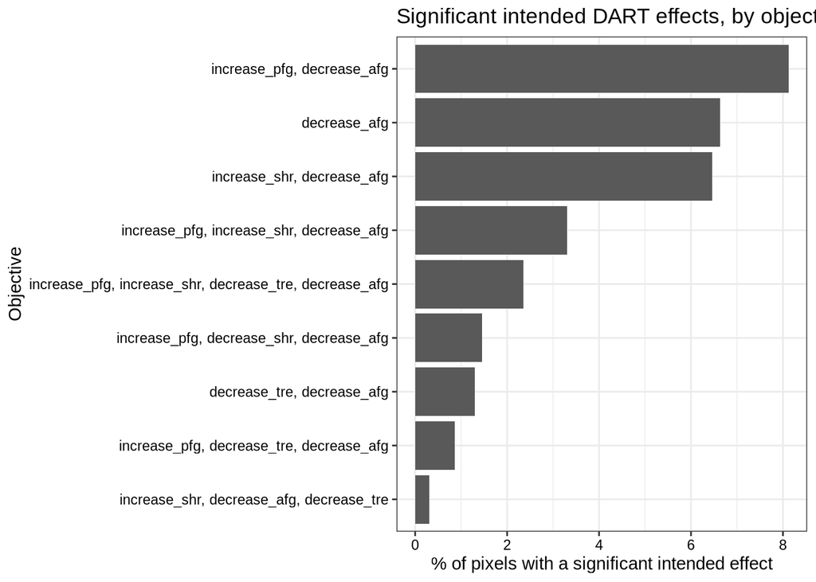

**Table and figure.** One row (and one bar) per *fine* objective string - the full comma-separated objective assignment of a pixel, so a pixel with compound objectives appears under its own combination rather than under each part. X axis of the figure: the percentage of that objective’s pixels with a significant *intended* effect - i.e. significant and in the direction decrease_afg was aiming for, which for this objective is a negative effect. Y axis: the fine objective, ordered by that percentage. Bars are a single grey fill; no colour grouping or facets. Across the 9 fine objectives present, the rate ranges from 0.31% to 8.12%. Because the sign is taken relative to this objective’s goal, these percentages are comparable *within* this section but not against another objective’s version of the same figure - the cross-objective tables at the end of the report use the raw sign for that reason.

Repeated for treatment:

| Treatment | Total Pixels | Significant Intended Pixels | % Significant Intended |
| --- | --- | --- | --- |
| vegetation removal | 15870 | 2232 | 14.06 |
| seeding;vegetation removal | 6086 | 288 | 4.73 |
| seeding;soil disturbance;vegetation removal | 11245 | 524 | 4.66 |
| seeding;soil disturbance | 22352 | 997 | 4.46 |
| seeding | 27645 | 518 | 1.87 |
| soil disturbance;vegetation removal | 977 | 6 | 0.61 |

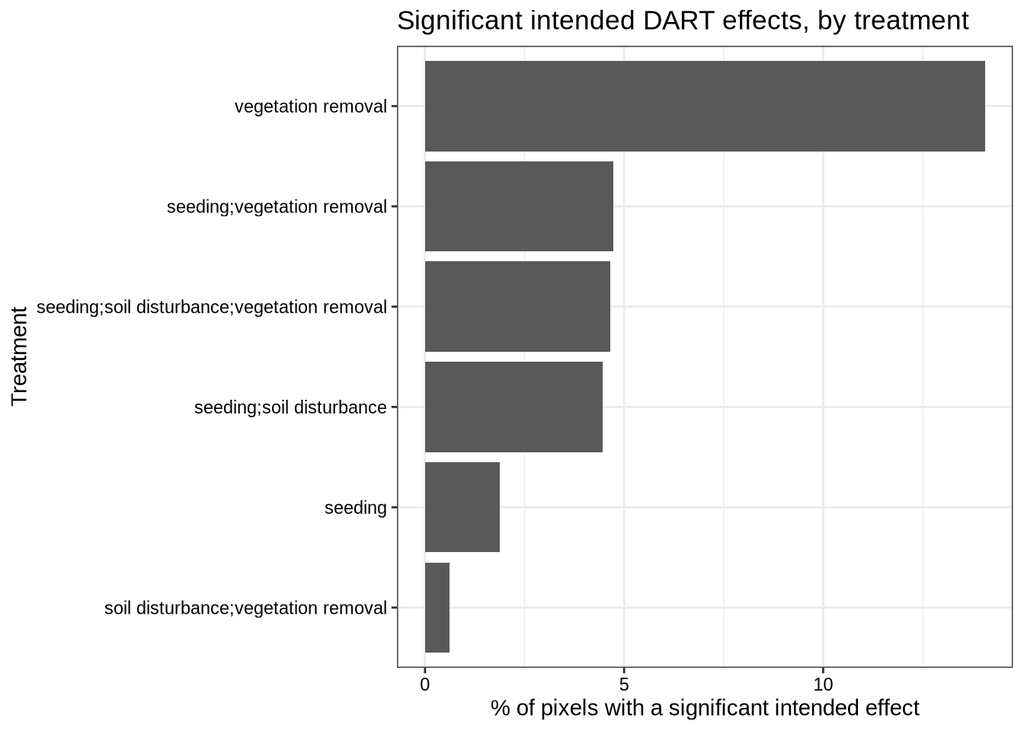

**Table and figure.** As above, grouped by coarse treatment (`'tx_coarse'`). X axis: % of that treatment’s pixels with a significant *intended* (negative) effect. Y axis: treatment, ordered by that percentage. Single grey fill, no facets. Range across the 6 treatments: 0.61% to 14.06%. This is the closest thing in the report to a per-treatment success rate for this objective, since the direction counted is the one the treatment was trying to produce.

Lastly, for ecoregion:

| Ecoregion | Total Pixels | Significant Intended Pixels | % Significant Intended |
| --- | --- | --- | --- |
| Uinta Basin Floor | 1008 | 260 | 25.79 |
| Sagebrush Basins and Slopes | 26304 | 2333 | 8.87 |
| Mountain Valleys | 1701 | 115 | 6.76 |
| Shadscale-Dominated Saline Basins | 15220 | 864 | 5.68 |
| Semiarid Hills and Low Mountains | 1204 | 64 | 5.32 |
| Semiarid Foothills | 4857 | 183 | 3.77 |
| Escarpments | 2937 | 97 | 3.30 |
| Northern Uinta Basin Slopes | 1501 | 40 | 2.66 |
| Semiarid Benchlands and Canyonlands | 8506 | 219 | 2.57 |
| Foothill Shrublands and Low Mountains | 900 | 21 | 2.33 |
| Woodland- and Shrub-Covered Low Mountains | 15669 | 335 | 2.14 |
| Dissected High Lava Plateau | 2828 | 26 | 0.92 |
| Rolling Sagebrush Steppe | 874 | 6 | 0.69 |
| Monticello-Cortez Uplands | 666 | 2 | 0.30 |

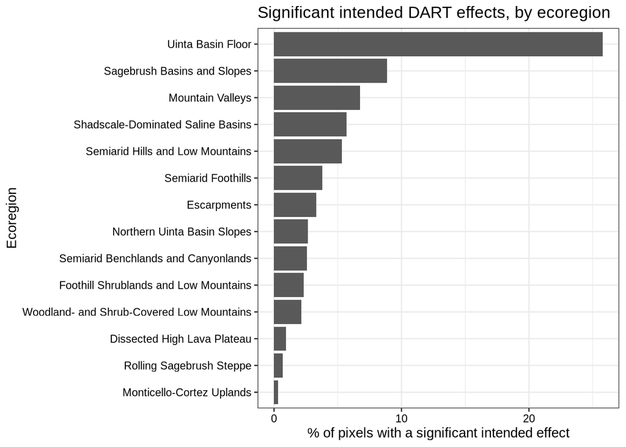

**Table and figure.** As above, grouped by level-IV ecoregion (`'us_l4name'`). X axis: % of that ecoregion’s pixels with a significant *intended* (negative) effect. Y axis: ecoregion, ordered by that percentage. Single grey fill, no facets. Range across the 14 ecoregions: 0.30% to 25.79%.

#### Significant DART effects, through time

The same effects along the time axis and against the covariates that interact with it: how often a significant effect occurred in each year since treatment, how large those effects were and when they peaked, and how the per-polygon peak years distribute across treatments and ecoregions. Read the two halves as separate questions - a year can carry a high significance rate with small effects, or the reverse.

##### How does time since treatment affect significance?

This section attempts to answer two questions:

1. How *often* does a significant effect show up in a given year? The stacked-direction figure immediately below.
2. How *large* are those effects? The mean-effect table and figure further down. A year can have a handful of significant pixels that each moved a long way, or many pixels that each moved a little, and those are different results.

No weighting is used anywhere in this section. The mean effect per year is a plain arithmetic mean of `effect` over the significant pixels in that year, split by direction of effect, so the reported peak is the year whose significant pixels actually moved furthest rather than a significance-weighted compromise across the whole time series. Some weighting methods were checked and did not improve the results - see `weight_testing_summary.Rmd` for that analysis.

Everything in this section is drawn on the **truncated** series: for this objective the record is cut at year 26, because year 27 was the first with fewer than 10 significant pixels. This is what stops a peak year being reported from the part of the record where almost nothing was significant; it also means the x axis here can end earlier than another objective’s, so the two are not read off the same range.

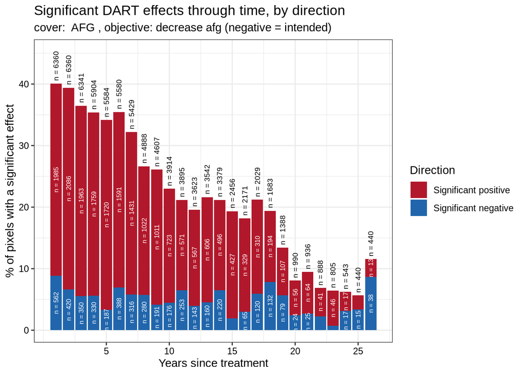

**Figure.** X axis: years since treatment, one bar per year, labelled every 5 years. Y axis: the percentage of that year’s pixels with a significant DART effect - the full height of a bar is the year’s overall % significant, and it is a percentage of all pixels observed in that year, not of the significant ones. Fill: the direction of the significant effect, splitting each bar into a blue *significant negative* component and a red *significant positive* component; the intended direction for this objective (negative) is the segment drawn against the axis, with the unintended direction stacked above it. Fill colours mean the same thing in every direction figure in this report. There are no facets or other groupings.

Two different sample sizes are labelled on each bar, and they are **not** meant to sum to each other:

- The rotated label sitting *above* each bar is that year’s **group total** - every pixel observed in that year, significant or not. It says how much data is behind the bar, and it is the denominator of the percentage on the Y axis.
- The white label *inside* each stacked segment is the number of pixels that were significant **and** in that segment’s direction. These two are the sample sizes behind the two segment heights themselves.

So the two segment labels add up to the number of *significant* pixels in that year, which is generally far smaller than the group total above the bar, because most pixels in a year are not significant. Reading down a tall bar with a small group total is therefore a different situation from a short bar with a large one, which is exactly why both numbers are drawn. Segments too short to hold their label legibly are left unlabelled to avoid white text spilling onto the panel background.

- Treatment was **most** effective (highest % significant pixels) at year 1 (40.0% significant).
- Treatment was **least** effective (lowest % significant pixels) at year 25 (5.7% significant).

##### How large were the significant effects in each year?

The figure below switches from counting significant pixels to measuring them: among significant pixels only, what was the mean DART effect in each year since treatment, and in which year was that mean largest? Positive and negative effects are summarized separately throughout.

| Direction | Peak Year | Mean Effect at Peak | SE | Significant Pixels at Peak | Last Year Observed | Peak Censored? |
| --- | --- | --- | --- | --- | --- | --- |
| negative | 18 | -43.2565 | 1.7902 | 132 | 26 | FALSE |
| positive | 25 | 28.7774 | 3.5268 | 10 | 26 | FALSE |

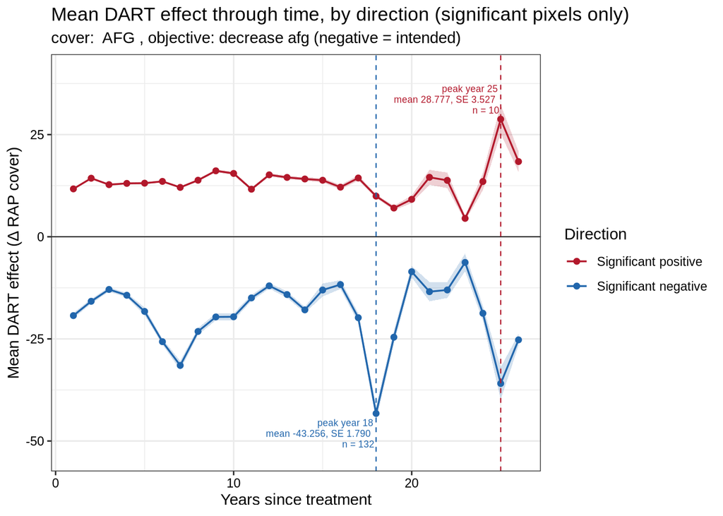

**Table.** One row per direction of effect: the year in which the mean effect over significant pixels was largest in magnitude, that mean, its SE, the number of significant pixels behind it, the last year observed for that direction, and whether the peak is censored (lands on that last year).

**Figure.** X axis: years since treatment. Y axis: the mean DART effect (Δ RAP cover) among *significant pixels only* in that year, computed separately for each direction - so the two series sit either side of the zero line by construction and are never averaged into a single number. Colour: direction of the effect (red = significant positive, blue = significant negative), using the same colours as the stacked figure above. The shaded band around each line is that year × direction mean ± 1 SE: it is sampling uncertainty in the *mean* effect, not the spread of individual pixel effects, so it narrows mainly where a year has many significant pixels. A year × direction cell backed by a single significant pixel has no SE and is drawn as a bare point, keeping the line through it unbroken. Dashed vertical lines mark each direction’s peak year from the table above, labelled with the mean effect at the peak, its SE, and the number of significant pixels behind it. Non-significant pixels are excluded outright rather than entered as zeros, and no weighting is applied anywhere. There are no facets or other groupings.

- Significant **negative** effects were largest at year 18 (mean effect -43.2565, SE 1.7902, n = 132 significant pixels).
- Significant **positive** effects were largest at year 25 (mean effect 28.7774, SE 3.5268, n = 10 significant pixels).

Note that the year with the largest mean effect need not be the year with the most significant pixels: the two questions can peak at different times, and a peak that lands on the last observed year is flagged as censored above for the same reason as in the by-polygon table further down.

| Objective | Cover | Year Bin | Total Pixels | Mean % Significant | Mean % Significant Positive | Mean % Significant Negative |
| --- | --- | --- | --- | --- | --- | --- |
| decrease_afg | AFG | 1-5 | 30549 | 37.19 | 31.14 | 6.05 |
| decrease_afg | AFG | 6-10 | 24418 | 29.20 | 23.66 | 5.53 |
| decrease_afg | AFG | 11-15 | 16895 | 20.66 | 15.79 | 4.88 |
| decrease_afg | AFG | 16+ | 12313 | 14.03 | 9.64 | 4.39 |

**Table.** The same significance rates as the year-by-year figure, collapsed into 1-5, 6-10, 11-15 and 16+ years since treatment. One row per bin; percentages are of all pixels in that bin, and the two directional columns sum to the overall column up to rounding.

| Treatment | N Polygons | Mean Year of Peak Sig. | SD | Min | Max | % Censored (peak at last obs. year) |
| --- | --- | --- | --- | --- | --- | --- |
| seeding | 32 | 4.31 | 5.92 | 1 | 26 | 3.1 |
| seeding;soil disturbance | 21 | 6.19 | 5.35 | 1 | 18 | 4.8 |
| seeding;soil disturbance;vegetation removal | 16 | 3.81 | 2.95 | 1 | 11 | 0.0 |
| seeding;vegetation removal | 18 | 2.83 | 1.79 | 1 | 7 | 5.6 |
| soil disturbance;vegetation removal | 2 | 3.50 | 3.54 | 1 | 6 | 0.0 |
| vegetation removal | 15 | 3.07 | 2.99 | 1 | 11 | 0.0 |

| Ecoregion | N Polygons | Mean Year of Peak Sig. | SD | Min | Max | % Censored (peak at last obs. year) |
| --- | --- | --- | --- | --- | --- | --- |
| Dissected High Lava Plateau | 2 | 3.00 | 2.83 | 1 | 5 | 0.0 |
| Escarpments | 6 | 5.50 | 4.51 | 2 | 14 | 0.0 |
| Foothill Shrublands and Low Mountains | 1 | 1.00 |  | 1 | 1 | 0.0 |
| Monticello-Cortez Uplands | 1 | 2.00 |  | 2 | 2 | 0.0 |
| Mountain Valleys | 3 | 5.67 | 5.03 | 1 | 11 | 0.0 |
| Northern Uinta Basin Slopes | 1 | 2.00 |  | 2 | 2 | 0.0 |
| Rolling Sagebrush Steppe | 1 | 4.00 |  | 4 | 4 | 0.0 |
| Sagebrush Basins and Slopes | 30 | 4.57 | 5.98 | 1 | 26 | 3.3 |
| Semiarid Benchlands and Canyonlands | 14 | 3.64 | 3.18 | 1 | 10 | 0.0 |
| Semiarid Foothills | 10 | 3.10 | 2.13 | 1 | 6 | 0.0 |
| Semiarid Hills and Low Mountains | 2 | 4.00 | 0.00 | 4 | 4 | 0.0 |
| Shadscale-Dominated Saline Basins | 6 | 10.67 | 5.47 | 4 | 18 | 16.7 |
| Uinta Basin Floor | 1 | 3.00 |  | 3 | 3 | 0.0 |
| Woodland- and Shrub-Covered Low Mountains | 26 | 2.85 | 3.12 | 1 | 15 | 3.8 |

**Tables.** Each polygon is reduced to the single year in which its own % significant pixels was highest (“peak significance year”); those per-polygon peak years are then summarized across polygons, by treatment in the first table and by ecoregion in the second. Columns: number of polygons behind the row, mean / SD / min / max of the peak year, and the percentage of polygons whose peak fell on the last year they were observed. A polygon’s peak year is flagged as “censored” in those cases, because we can’t rule out that significance was still rising beyond the end of the available time series. Note that “last year observed” now means the last year *retained* after the late-year truncation described above, so where a series was truncated the censoring flag is partly an artefact of the threshold rather than of the record itself - it marks the end of the analysable series, not necessarily the end of the data. What that censoring implies is taken up under *Interpretation* at the end of the report.

#### Overall results and interpretation

##### Summary statistics

What the three sample-size filters cost this objective x cover response, in one row - the same quantities reported in prose under *Results after dropping* above, gathered here so that this subsection stands on its own. The identical row appears in the cross-objective filtering log in `2_make_DART_results.Rmd`, where it can be read against the other objectives.

| Objective | Cover | Min Pixels per Tx x Eco | # Tx x Eco Excluded | # Tx Depopulated | # Eco Depopulated | Min Pixels per Year | Year Truncated At | # Years Dropped | % Pixels Lost | # Tx Absent | # Eco Absent |
| --- | --- | --- | --- | --- | --- | --- | --- | --- | --- | --- | --- |
| decrease_afg | AFG | 300 | 20 | 0 | 0 | 10 | 27 | 2 | 2.53 | 3 | 4 |

**Table.** One row for this objective x cover response. `% Pixels Lost` is the combined cost of all three filters, not the cell filter alone. `# Tx Absent` / `# Eco Absent` count levels missing from the post-filter data for any reason, which is a different quantity from the two depopulated columns: a level that only ever appeared in sparse cells disappears without the depopulation filter being involved.

Post-filter, this objective x cover response retains 84175 pixels across 6 treatment level(s) and 14 ecoregion level(s), the smallest surviving totals being 977 pixels for a treatment and 666 for an ecoregion, against a per-cell threshold of 300.

##### Interpretation

- This was the only objective that achieved mostly the opposite of what it intended in that the direction of effect was usually positive, while the attempted effect was negative. I would hypothesize that the very strong unintended-effect result has to do with disturbance effects or the interact effects of compound objectives.
- Significance patterns over fine objectives are highly heterogenous, but too complex to interpret casually.
- Significance patterns over treatments are also highly heterogenous, but similarily complex.
- Significance patterns over ecoregion probably require some environmental context, or an expert eye. For example I don’t have enough personal knowledge to guess why `Uinta Basin Floor` was so much higher than the other ecoregions.”
- Treatment was generally not successful.

### cover: SHR , objective: decrease shr

#### Sample sizes and scope

How much data backs this objective x cover response, how much of it the three sample-size filters removed, and how much of it is shared with other objectives. Everything here is descriptive: no treatment effect is reported in this subsection. Pixel counts are shown per treatment x ecoregion cell, which is the unit the first filter works on, and then again per treatment and per ecoregion *after* filtering - the pre-filter totals by treatment and by ecoregion were dropped as unhelpful, since nothing downstream is built on them.

##### Pixel counts for each treatment × ecoregion combination (`'tx_coarse'` x `'us_l4name'`)

Each level of (treatment x ecoregion) is filtered here for low sample size (300 pixels).

|  | Dissected High Lava Plateau | Escarpments | Foothill Shrublands and Low Mountains | Mountain Valleys | Sagebrush Basins and Slopes | Semiarid Benchlands and Canyonlands | Semiarid Foothills | Shadscale-Dominated Saline Basins | Wasatch Montane Zone | Woodland- and Shrub-Covered Low Mountains |
| --- | --- | --- | --- | --- | --- | --- | --- | --- | --- | --- |
| prescribed burn | 0 | 400 | 0 | 0 | 1764 | 115320 | 0 | 0 | 260 | 6642 |
| prescribed burn;seeding | 0 | 5616 | 0 | 93 | 0 | 0 | 1890 | 0 | 0 | 0 |
| prescribed burn;seeding;soil disturbance | 0 | 0 | 120 | 0 | 0 | 0 | 0 | 0 | 0 | 0 |
| prescribed burn;soil disturbance;vegetation removal | 0 | 0 | 0 | 0 | 0 | 0 | 0 | 0 | 0 | 6066 |
| prescribed burn;vegetation removal | 0 | 0 | 0 | 0 | 0 | 0 | 1750 | 0 | 0 | 0 |
| seeding | 0 | 0 | 0 | 0 | 315 | 1122 | 0 | 0 | 0 | 0 |
| seeding;soil disturbance | 0 | 0 | 0 | 722 | 4187 | 2734 | 2571 | 0 | 72 | 2436 |
| seeding;soil disturbance;vegetation removal | 100 | 0 | 0 | 0 | 2530 | 318 | 2193 | 3750 | 0 | 804 |
| seeding;vegetation removal | 0 | 0 | 0 | 408 | 0 | 72 | 560 | 0 | 0 | 0 |
| soil disturbance | 0 | 0 | 0 | 0 | 1638 | 708 | 0 | 0 | 0 | 0 |
| soil disturbance;vegetation removal | 0 | 0 | 0 | 0 | 396 | 0 | 0 | 0 | 0 | 0 |
| vegetation removal | 0 | 14 | 0 | 410 | 2163 | 12170 | 3949 | 0 | 1170 | 108 |

|  | Dissected High Lava Plateau | Escarpments | Foothill Shrublands and Low Mountains | Mountain Valleys | Semiarid Benchlands and Canyonlands | Wasatch Montane Zone | Woodland- and Shrub-Covered Low Mountains |
| --- | --- | --- | --- | --- | --- | --- | --- |
| prescribed burn |  |  |  |  |  | 260 |  |
| prescribed burn;seeding |  |  |  | 93 |  |  |  |
| prescribed burn;seeding;soil disturbance |  |  | 120 |  |  |  |  |
| seeding;soil disturbance |  |  |  |  |  | 72 |  |
| seeding;soil disturbance;vegetation removal | 100 |  |  |  |  |  |  |
| seeding;vegetation removal |  |  |  |  | 72 |  |  |
| vegetation removal |  | 14 |  |  |  |  | 108 |

**Table.** The first table is the full pixel count for every treatment (rows) x ecoregion (columns) combination; the second keeps only the cells that are non-zero but below the 300-pixel threshold, i.e. the combinations that are present but too sparse to analyse. Empty cells in the second table are combinations that are either absent or above the threshold.

| Treatment | Ecoregion |
| --- | --- |
| seeding;soil disturbance;vegetation removal | Dissected High Lava Plateau |
| vegetation removal | Escarpments |
| prescribed burn;seeding;soil disturbance | Foothill Shrublands and Low Mountains |
| prescribed burn;seeding | Mountain Valleys |
| seeding;vegetation removal | Semiarid Benchlands and Canyonlands |
| prescribed burn | Wasatch Montane Zone |
| seeding;soil disturbance | Wasatch Montane Zone |
| vegetation removal | Woodland- and Shrub-Covered Low Mountains |

**Table.** 8 treatment x ecoregion combinations fall below the 300-pixel threshold, representing 0.45% of the total sample size for this objective x cover response. Each row is one combination that will be dropped below.

**Are these sparse combinations especially significant (or non-significant)?**

| Treatment | Ecoregion | Significant Pixels | Total Pixels | % Significant Pixels |
| --- | --- | --- | --- | --- |
| prescribed burn | Wasatch Montane Zone | 210 | 260 | 80.77 |
| prescribed burn;seeding | Mountain Valleys | 35 | 93 | 37.63 |
| prescribed burn;seeding;soil disturbance | Foothill Shrublands and Low Mountains | 17 | 120 | 14.17 |
| seeding;soil disturbance | Wasatch Montane Zone | 16 | 72 | 22.22 |
| seeding;soil disturbance;vegetation removal | Dissected High Lava Plateau | 38 | 100 | 38.00 |
| seeding;vegetation removal | Semiarid Benchlands and Canyonlands | 53 | 72 | 73.61 |
| vegetation removal | Escarpments | 0 | 14 | 0.00 |
| vegetation removal | Woodland- and Shrub-Covered Low Mountains | 83 | 108 | 76.85 |

**Table.** Significance rate within the sparse combinations only: one row per dropped treatment x ecoregion combination, giving its significant pixel count, its total pixel count, and the resulting percentage. Compare against the overall rate reported further down to see whether the dropped cells were unusual.

##### Results after dropping (treatment x ecoregion)

The pixel cutoff for each (treatment × ecoregion) combination was 300.

Three filters have now been applied to this objective x cover response, in this order, and the percentage below is the combined cost of all three:

1. **Sparse (treatment x ecoregion) cells** - the 8 combinations listed above, below 300 pixels each.
2. **Depopulated treatment or ecoregion levels** - on, at the same 300-pixel threshold: 0 treatment and 0 ecoregion level(s) removed. This catches a level thinned across many surviving cells, which the cell filter cannot see.
3. **Late-year truncation** - year 33 was the first below 10 significant pixels, so it and the 0 year(s) after it were dropped; the series now ends at year 32.

Total data lost across all three: **0.50%**. Treatment levels absent from the post-filter data: `prescribed burn;seeding;soil disturbance`. Ecoregion levels absent: `Foothill Shrublands and Low Mountains`, `Dissected High Lava Plateau`. (These are levels gone for *any* reason - a level that only ever appeared in sparse cells disappears without the depopulation filter being involved.)

The post-filter totals below are the check that the three filters together have not left some treatment or ecoregion analysable in name only.

| Treatment | Pixel Count (post-filter) |
| --- | --- |
| prescribed burn | 124020 |
| prescribed burn;seeding | 7506 |
| prescribed burn;soil disturbance;vegetation removal | 6066 |
| prescribed burn;vegetation removal | 1750 |
| seeding | 1437 |
| seeding;soil disturbance | 12650 |
| seeding;soil disturbance;vegetation removal | 9595 |
| seeding;vegetation removal | 968 |
| soil disturbance | 2346 |
| soil disturbance;vegetation removal | 396 |
| vegetation removal | 19862 |

| Ecoregion | Pixel Count (post-filter) |
| --- | --- |
| Escarpments | 6016 |
| Mountain Valleys | 1540 |
| Sagebrush Basins and Slopes | 12993 |
| Semiarid Benchlands and Canyonlands | 132266 |
| Semiarid Foothills | 12913 |
| Shadscale-Dominated Saline Basins | 3750 |
| Wasatch Montane Zone | 1170 |
| Woodland- and Shrub-Covered Low Mountains | 15948 |

**Tables.** Post-filter pixel totals, by treatment and by ecoregion, after the sparse combinations above were dropped. The smallest surviving treatment total is 396 pixels and the smallest surviving ecoregion total is 1170 pixels, against a combination-level threshold of 300.

##### How often does this objective overlap with other objectives?

| Objective | Cover | Co-occurring Objective | Pixel Count | % of Total Pixels |
| --- | --- | --- | --- | --- |
| decrease_shr | SHR | none | 8560 | 4.59 |
| decrease_shr | SHR | increase_pfg | 158996 | 85.21 |
| decrease_shr | SHR | decrease_tre | 152872 | 81.93 |
| decrease_shr | SHR | decrease_afg | 4101 | 2.20 |
| decrease_shr | SHR | null_afg | 2684 | 1.44 |
| decrease_shr | SHR | increase_afg | 501 | 0.27 |

**Table.** Among pixels assigned to decrease_shr, how often each *other* objective was also assigned to that same pixel. The first row (`none`) is the pixels that carried no other objective. Percentages are shares of this objective’s own (post-filter) pixel total, so they sum to more than 100% wherever pixels carry more than two objectives.

#### Pixel and polygon counts, post-filtering

Pixel counts per polygon, excluding zeros, *i.e.* no pixels present for that `'tx_coarse'` x `'us_l4name'` combination):

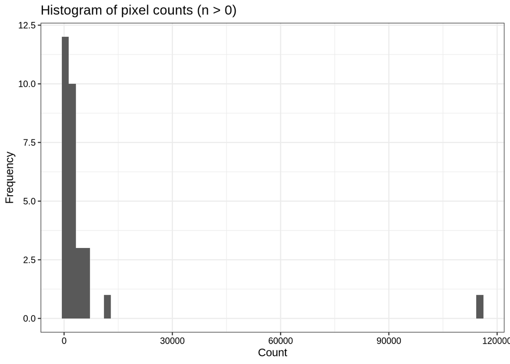

**Figure.** X axis: the pixel count of a single treatment x ecoregion cell. Y axis: how many such cells fall in that count bin (frequency). Cells with zero pixels are excluded, so the distribution describes only combinations that exist in the data. No groupings, colours or facets.

Polygon count table, plotted as histogram, zeroes excluded:

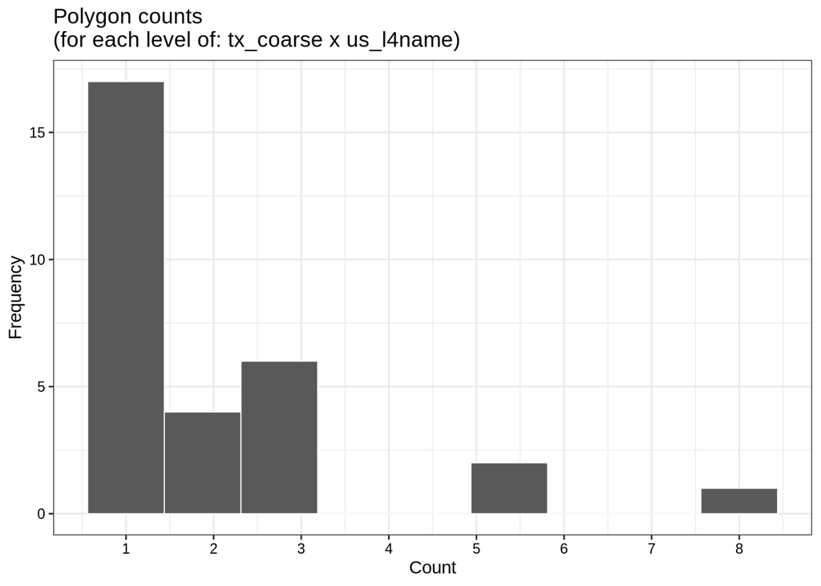

**Figure.** X axis: the number of distinct polygons in a single treatment x ecoregion cell, with one break per integer. Y axis: how many cells have that polygon count (frequency). Zero-polygon cells are excluded. No groupings, colours or facets.

Polygon count table: for each year since treatment, how many distinct polygons contribute at least one pixel that year.

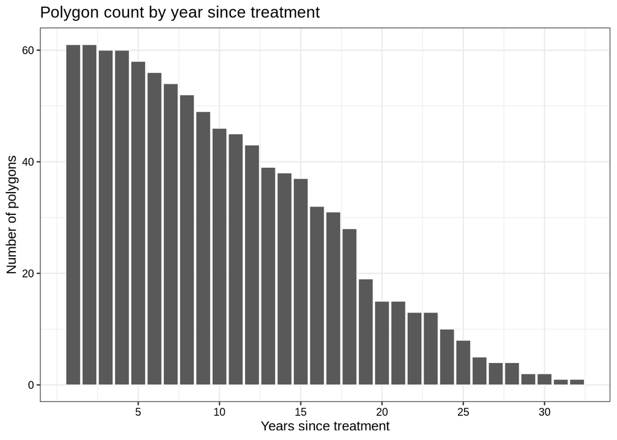

**Figure.** X axis: years since treatment, labelled every 5 years. Y axis: the number of distinct polygons contributing at least one pixel in that year - i.e. how many independent spatial replicates back that year, which is a different quantity from the year’s pixel count. No groupings, colours or facets.

#### Significant DART effects, by covariate

How often a significant effect occurred, first as one rate for the whole objective and then broken apart by fine objective, by treatment and by ecoregion. All of it is cross-sectional - the time dimension is the next subsection - and all of it reports the *intended* effect, since every level on these axes shares this objective’s management goal.

##### How many pixels have a significant DART result?

DART results are considered significant if the confidence intervals for each DART estimate do not include zero.

| Objective | Cover | Total Pixels | % Significant | % Significant Positive | % Significant Negative |
| --- | --- | --- | --- | --- | --- |
| decrease_shr | SHR | 186596 | 15 | 4.7 | 10.3 |

The same total expressed as intended versus unintended rather than as raw sign: 15% of all DART pixels were significant, with the treatment producing the intended (negative) effect in 10.3% of pixels and an unintended (positive) effect in 4.7% of pixels, relative to the assigned objective.

##### How do DART significance patterns change

| Objective (Fine) | Total Pixels | Significant Intended Pixels | % Significant Intended |
| --- | --- | --- | --- |
| increase_pfg, increase_afg, decrease_shr | 501 | 132 | 26.35 |
| increase_pfg, decrease_shr | 20562 | 3504 | 17.04 |
| decrease_shr | 8560 | 1213 | 14.17 |
| decrease_shr, decrease_tre | 18668 | 2206 | 11.82 |
| increase_pfg, decrease_shr, decrease_tre | 131148 | 11680 | 8.91 |
| increase_pfg, decrease_shr, decrease_afg | 4101 | 355 | 8.66 |
| increase_pfg, decrease_shr, decrease_tre, null_afg | 2684 | 157 | 5.85 |
| decrease_tre, decrease_shr | 372 | 0 | 0.00 |

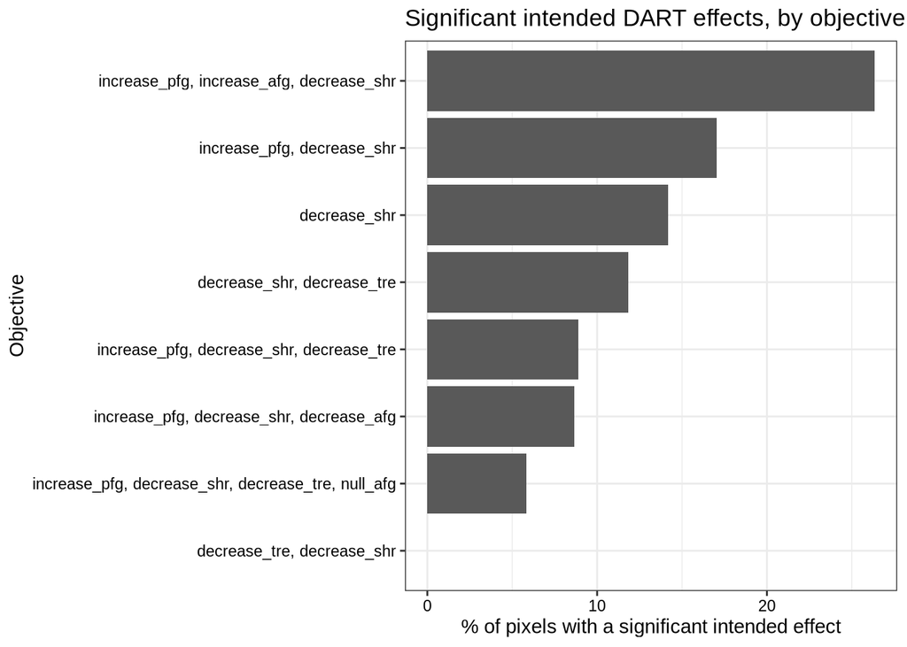

**Table and figure.** One row (and one bar) per *fine* objective string - the full comma-separated objective assignment of a pixel, so a pixel with compound objectives appears under its own combination rather than under each part. X axis of the figure: the percentage of that objective’s pixels with a significant *intended* effect - i.e. significant and in the direction decrease_shr was aiming for, which for this objective is a negative effect. Y axis: the fine objective, ordered by that percentage. Bars are a single grey fill; no colour grouping or facets. Across the 8 fine objectives present, the rate ranges from 0.00% to 26.35%. Because the sign is taken relative to this objective’s goal, these percentages are comparable *within* this section but not against another objective’s version of the same figure - the cross-objective tables at the end of the report use the raw sign for that reason.

Repeated for treatment:

| Treatment | Total Pixels | Significant Intended Pixels | % Significant Intended |
| --- | --- | --- | --- |
| seeding | 1437 | 347 | 24.15 |
| soil disturbance | 2346 | 507 | 21.61 |
| prescribed burn;vegetation removal | 1750 | 375 | 21.43 |
| seeding;vegetation removal | 968 | 195 | 20.14 |
| seeding;soil disturbance | 12650 | 2153 | 17.02 |
| seeding;soil disturbance;vegetation removal | 9595 | 1591 | 16.58 |
| prescribed burn;soil disturbance;vegetation removal | 6066 | 875 | 14.42 |
| vegetation removal | 19862 | 2305 | 11.61 |
| soil disturbance;vegetation removal | 396 | 36 | 9.09 |
| prescribed burn | 124020 | 10732 | 8.65 |
| prescribed burn;seeding | 7506 | 131 | 1.75 |

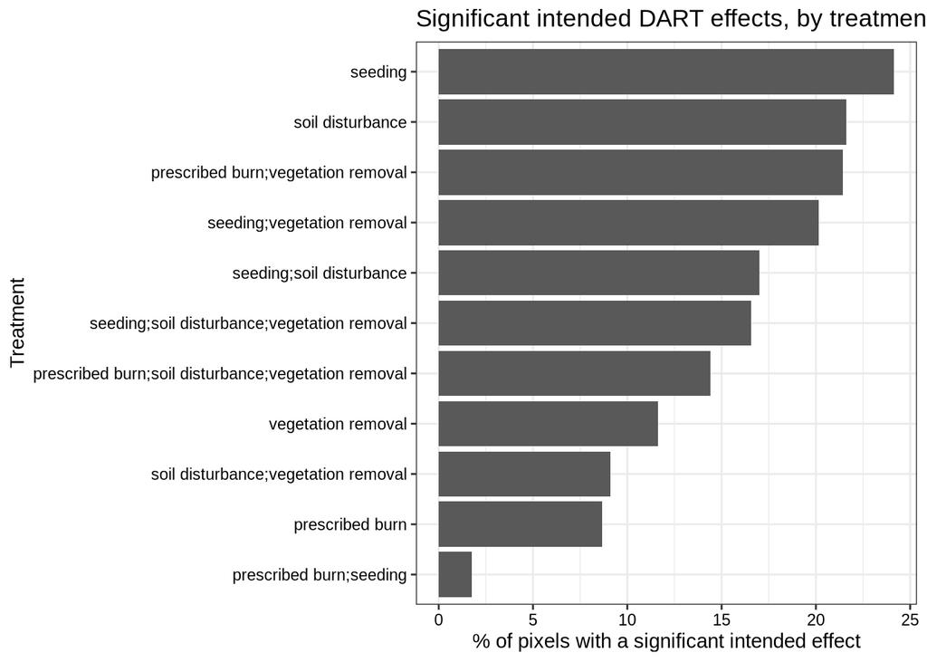

**Table and figure.** As above, grouped by coarse treatment (`'tx_coarse'`). X axis: % of that treatment’s pixels with a significant *intended* (negative) effect. Y axis: treatment, ordered by that percentage. Single grey fill, no facets. Range across the 11 treatments: 1.75% to 24.15%. This is the closest thing in the report to a per-treatment success rate for this objective, since the direction counted is the one the treatment was trying to produce.

Lastly, for ecoregion:

| Ecoregion | Total Pixels | Significant Intended Pixels | % Significant Intended |
| --- | --- | --- | --- |
| Sagebrush Basins and Slopes | 12993 | 3827 | 29.45 |
| Mountain Valleys | 1540 | 252 | 16.36 |
| Wasatch Montane Zone | 1170 | 153 | 13.08 |
| Semiarid Foothills | 12913 | 1487 | 11.52 |
| Woodland- and Shrub-Covered Low Mountains | 15948 | 1759 | 11.03 |
| Semiarid Benchlands and Canyonlands | 132266 | 11621 | 8.79 |
| Escarpments | 6016 | 108 | 1.80 |
| Shadscale-Dominated Saline Basins | 3750 | 40 | 1.07 |

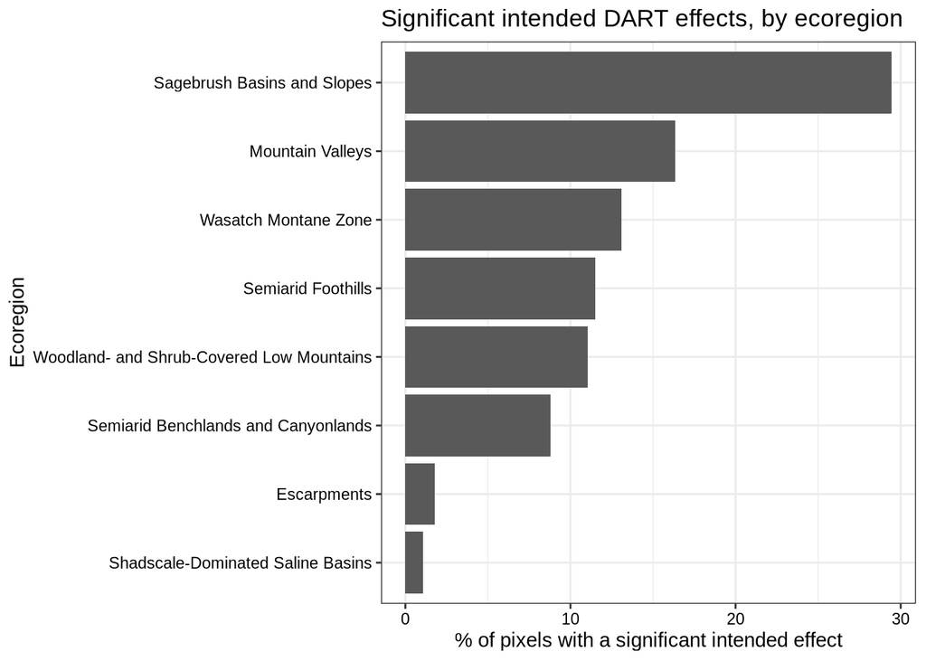

**Table and figure.** As above, grouped by level-IV ecoregion (`'us_l4name'`). X axis: % of that ecoregion’s pixels with a significant *intended* (negative) effect. Y axis: ecoregion, ordered by that percentage. Single grey fill, no facets. Range across the 8 ecoregions: 1.07% to 29.45%.

#### Significant DART effects, through time

The same effects along the time axis and against the covariates that interact with it: how often a significant effect occurred in each year since treatment, how large those effects were and when they peaked, and how the per-polygon peak years distribute across treatments and ecoregions. Read the two halves as separate questions - a year can carry a high significance rate with small effects, or the reverse.

##### How does time since treatment affect significance?

This section attempts to answer two questions:

1. How *often* does a significant effect show up in a given year? The stacked-direction figure immediately below.
2. How *large* are those effects? The mean-effect table and figure further down. A year can have a handful of significant pixels that each moved a long way, or many pixels that each moved a little, and those are different results.

No weighting is used anywhere in this section. The mean effect per year is a plain arithmetic mean of `effect` over the significant pixels in that year, split by direction of effect, so the reported peak is the year whose significant pixels actually moved furthest rather than a significance-weighted compromise across the whole time series. Some weighting methods were checked and did not improve the results - see `weight_testing_summary.Rmd` for that analysis.

Everything in this section is drawn on the **truncated** series: for this objective the record is cut at year 32, because year 33 was the first with fewer than 10 significant pixels. This is what stops a peak year being reported from the part of the record where almost nothing was significant; it also means the x axis here can end earlier than another objective’s, so the two are not read off the same range.

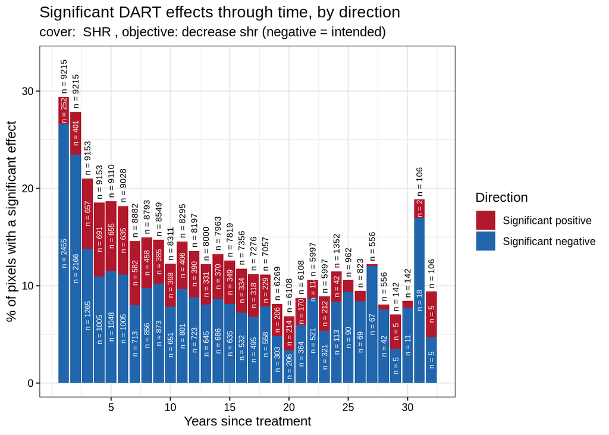

**Figure.** X axis: years since treatment, one bar per year, labelled every 5 years. Y axis: the percentage of that year’s pixels with a significant DART effect - the full height of a bar is the year’s overall % significant, and it is a percentage of all pixels observed in that year, not of the significant ones. Fill: the direction of the significant effect, splitting each bar into a blue *significant negative* component and a red *significant positive* component; the intended direction for this objective (negative) is the segment drawn against the axis, with the unintended direction stacked above it. Fill colours mean the same thing in every direction figure in this report. There are no facets or other groupings.

Two different sample sizes are labelled on each bar, and they are **not** meant to sum to each other:

- The rotated label sitting *above* each bar is that year’s **group total** - every pixel observed in that year, significant or not. It says how much data is behind the bar, and it is the denominator of the percentage on the Y axis.
- The white label *inside* each stacked segment is the number of pixels that were significant **and** in that segment’s direction. These two are the sample sizes behind the two segment heights themselves.

So the two segment labels add up to the number of *significant* pixels in that year, which is generally far smaller than the group total above the bar, because most pixels in a year are not significant. Reading down a tall bar with a small group total is therefore a different situation from a short bar with a large one, which is exactly why both numbers are drawn. Segments too short to hold their label legibly are left unlabelled to avoid white text spilling onto the panel background.

- Treatment was **most** effective (highest % significant pixels) at year 1 (29.4% significant).
- Treatment was **least** effective (lowest % significant pixels) at year 20 (6.9% significant).

##### How large were the significant effects in each year?

The figure below switches from counting significant pixels to measuring them: among significant pixels only, what was the mean DART effect in each year since treatment, and in which year was that mean largest? Positive and negative effects are summarized separately throughout.

| Direction | Peak Year | Mean Effect at Peak | SE | Significant Pixels at Peak | Last Year Observed | Peak Censored? |
| --- | --- | --- | --- | --- | --- | --- |
| negative | 1 | -21.3814 | 0.2574 | 2455 | 32 | FALSE |
| positive | 27 | 14.1992 | NA | 1 | 32 | FALSE |

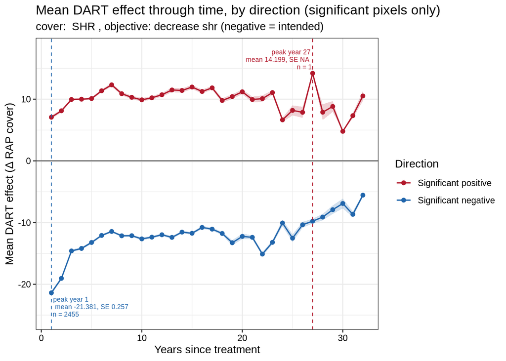

**Table.** One row per direction of effect: the year in which the mean effect over significant pixels was largest in magnitude, that mean, its SE, the number of significant pixels behind it, the last year observed for that direction, and whether the peak is censored (lands on that last year).

**Figure.** X axis: years since treatment. Y axis: the mean DART effect (Δ RAP cover) among *significant pixels only* in that year, computed separately for each direction - so the two series sit either side of the zero line by construction and are never averaged into a single number. Colour: direction of the effect (red = significant positive, blue = significant negative), using the same colours as the stacked figure above. The shaded band around each line is that year × direction mean ± 1 SE: it is sampling uncertainty in the *mean* effect, not the spread of individual pixel effects, so it narrows mainly where a year has many significant pixels. A year × direction cell backed by a single significant pixel has no SE and is drawn as a bare point, keeping the line through it unbroken. Dashed vertical lines mark each direction’s peak year from the table above, labelled with the mean effect at the peak, its SE, and the number of significant pixels behind it. Non-significant pixels are excluded outright rather than entered as zeros, and no weighting is applied anywhere. There are no facets or other groupings.

- Significant **negative** effects were largest at year 1 (mean effect -21.3814, SE 0.2574, n = 2455 significant pixels).
- Significant **positive** effects were largest at year 27 (mean effect 14.1992, SE NA, n = 1 significant pixels).

Note that the year with the largest mean effect need not be the year with the most significant pixels: the two questions can peak at different times, and a peak that lands on the last observed year is flagged as censored above for the same reason as in the by-polygon table further down.

| Objective | Cover | Year Bin | Total Pixels | Mean % Significant | Mean % Significant Positive | Mean % Significant Negative |
| --- | --- | --- | --- | --- | --- | --- |
| decrease_shr | SHR | 1-5 | 45846 | 23.11 | 5.79 | 17.32 |
| decrease_shr | SHR | 6-10 | 43563 | 14.98 | 5.57 | 9.41 |
| decrease_shr | SHR | 11-15 | 40274 | 13.25 | 4.58 | 8.67 |
| decrease_shr | SHR | 16+ | 56913 | 9.83 | 3.30 | 6.54 |

**Table.** The same significance rates as the year-by-year figure, collapsed into 1-5, 6-10, 11-15 and 16+ years since treatment. One row per bin; percentages are of all pixels in that bin, and the two directional columns sum to the overall column up to rounding.

| Treatment | N Polygons | Mean Year of Peak Sig. | SD | Min | Max | % Censored (peak at last obs. year) |
| --- | --- | --- | --- | --- | --- | --- |
| prescribed burn | 7 | 7.14 | 7.80 | 1 | 23 | 0.0 |
| prescribed burn;seeding | 2 | 4.00 | 2.83 | 2 | 6 | 0.0 |
| prescribed burn;soil disturbance;vegetation removal | 1 | 14.00 |  | 14 | 14 | 0.0 |
| prescribed burn;vegetation removal | 1 | 6.00 |  | 6 | 6 | 0.0 |
| seeding | 2 | 1.00 | 0.00 | 1 | 1 | 0.0 |
| seeding;soil disturbance | 15 | 5.13 | 5.36 | 1 | 19 | 6.7 |
| seeding;soil disturbance;vegetation removal | 8 | 4.12 | 2.75 | 1 | 9 | 0.0 |
| seeding;vegetation removal | 2 | 4.00 | 4.24 | 1 | 7 | 50.0 |
| soil disturbance | 4 | 2.25 | 0.96 | 1 | 3 | 0.0 |
| soil disturbance;vegetation removal | 1 | 16.00 |  | 16 | 16 | 0.0 |
| vegetation removal | 18 | 6.78 | 5.22 | 1 | 21 | 11.1 |

| Ecoregion | N Polygons | Mean Year of Peak Sig. | SD | Min | Max | % Censored (peak at last obs. year) |
| --- | --- | --- | --- | --- | --- | --- |
| Escarpments | 2 | 6.00 | 0.00 | 6 | 6 | 0.0 |
| Mountain Valleys | 4 | 6.75 | 8.26 | 1 | 19 | 25.0 |
| Sagebrush Basins and Slopes | 14 | 3.93 | 4.21 | 1 | 16 | 0.0 |
| Semiarid Benchlands and Canyonlands | 19 | 5.16 | 5.62 | 1 | 21 | 5.3 |
| Semiarid Foothills | 12 | 6.17 | 3.04 | 2 | 13 | 16.7 |
| Shadscale-Dominated Saline Basins | 1 | 5.00 |  | 5 | 5 | 0.0 |
| Wasatch Montane Zone | 1 | 6.00 |  | 6 | 6 | 0.0 |
| Woodland- and Shrub-Covered Low Mountains | 8 | 8.50 | 7.78 | 1 | 23 | 0.0 |

**Tables.** Each polygon is reduced to the single year in which its own % significant pixels was highest (“peak significance year”); those per-polygon peak years are then summarized across polygons, by treatment in the first table and by ecoregion in the second. Columns: number of polygons behind the row, mean / SD / min / max of the peak year, and the percentage of polygons whose peak fell on the last year they were observed. A polygon’s peak year is flagged as “censored” in those cases, because we can’t rule out that significance was still rising beyond the end of the available time series. Note that “last year observed” now means the last year *retained* after the late-year truncation described above, so where a series was truncated the censoring flag is partly an artefact of the threshold rather than of the record itself - it marks the end of the analysable series, not necessarily the end of the data. What that censoring implies is taken up under *Interpretation* at the end of the report.

#### Overall results and interpretation

##### Summary statistics

What the three sample-size filters cost this objective x cover response, in one row - the same quantities reported in prose under *Results after dropping* above, gathered here so that this subsection stands on its own. The identical row appears in the cross-objective filtering log in `2_make_DART_results.Rmd`, where it can be read against the other objectives.

| Objective | Cover | Min Pixels per Tx x Eco | # Tx x Eco Excluded | # Tx Depopulated | # Eco Depopulated | Min Pixels per Year | Year Truncated At | # Years Dropped | % Pixels Lost | # Tx Absent | # Eco Absent |
| --- | --- | --- | --- | --- | --- | --- | --- | --- | --- | --- | --- |
| decrease_shr | SHR | 300 | 8 | 0 | 0 | 10 | 33 | 1 | 0.5 | 1 | 2 |

**Table.** One row for this objective x cover response. `% Pixels Lost` is the combined cost of all three filters, not the cell filter alone. `# Tx Absent` / `# Eco Absent` count levels missing from the post-filter data for any reason, which is a different quantity from the two depopulated columns: a level that only ever appeared in sparse cells disappears without the depopulation filter being involved.

Post-filter, this objective x cover response retains 186596 pixels across 11 treatment level(s) and 8 ecoregion level(s), the smallest surviving totals being 396 pixels for a treatment and 1170 for an ecoregion, against a per-cell threshold of 300.

##### Interpretation

- Treatment looked successful, but at a smaller magnitude than the other objectives
- needs more details

### cover: TRE , objective: decrease tre

#### Sample sizes and scope

How much data backs this objective x cover response, how much of it the three sample-size filters removed, and how much of it is shared with other objectives. Everything here is descriptive: no treatment effect is reported in this subsection. Pixel counts are shown per treatment x ecoregion cell, which is the unit the first filter works on, and then again per treatment and per ecoregion *after* filtering - the pre-filter totals by treatment and by ecoregion were dropped as unhelpful, since nothing downstream is built on them.

##### Pixel counts for each treatment × ecoregion combination (`'tx_coarse'` x `'us_l4name'`)

Each level of (treatment x ecoregion) is filtered here for low sample size (10 pixels).

|  | Crystalline Mid-Elevation Forests | Dissected High Lava Plateau | Escarpments | Foothill Shrublands and Low Mountains | High Elevation Forests and Shrublands | Mid-Elevation Uinta Mountains | Mountain Valleys | Northern Uinta Basin Slopes | Rolling Sagebrush Steppe | Sagebrush Basins and Slopes | Semiarid Benchlands and Canyonlands | Semiarid Foothills | Semiarid Hills and Low Mountains | Wasatch Montane Zone | Woodland- and Shrub-Covered Low Mountains |
| --- | --- | --- | --- | --- | --- | --- | --- | --- | --- | --- | --- | --- | --- | --- | --- |
| prescribed burn | 0 | 0 | 4713 | 110 | 0 | 0 | 0 | 0 | 0 | 0 | 144246 | 0 | 0 | 0 | 5796 |
| prescribed burn;seeding | 0 | 0 | 6452 | 0 | 0 | 0 | 155 | 0 | 0 | 0 | 6144 | 1890 | 0 | 0 | 0 |
| prescribed burn;seeding;soil disturbance | 0 | 0 | 0 | 0 | 0 | 0 | 0 | 0 | 0 | 0 | 75 | 0 | 0 | 0 | 0 |
| prescribed burn;seeding;soil disturbance;vegetation removal | 0 | 0 | 0 | 0 | 0 | 0 | 0 | 0 | 0 | 328 | 731 | 0 | 0 | 0 | 0 |
| prescribed burn;soil disturbance;vegetation removal | 0 | 0 | 0 | 0 | 0 | 0 | 0 | 0 | 0 | 3780 | 0 | 0 | 0 | 0 | 6066 |
| prescribed burn;vegetation removal | 0 | 0 | 0 | 0 | 0 | 0 | 0 | 0 | 0 | 780 | 0 | 18748 | 234 | 0 | 1388 |
| seeding | 0 | 0 | 0 | 0 | 0 | 0 | 18 | 0 | 0 | 0 | 1676 | 740 | 0 | 0 | 0 |
| seeding;soil disturbance | 0 | 5833 | 0 | 0 | 16 | 0 | 91 | 974 | 0 | 15881 | 10756 | 15897 | 1290 | 0 | 6768 |
| seeding;soil disturbance;vegetation removal | 0 | 100 | 612 | 0 | 0 | 0 | 0 | 0 | 0 | 2530 | 3703 | 4077 | 0 | 0 | 3341 |
| seeding;vegetation removal | 0 | 4453 | 363 | 252 | 0 | 377 | 556 | 0 | 60 | 2873 | 10344 | 4973 | 2730 | 0 | 11127 |
| soil disturbance | 0 | 2197 | 0 | 0 | 0 | 0 | 50 | 0 | 0 | 649 | 4436 | 1622 | 0 | 0 | 2613 |
| soil disturbance;vegetation removal | 0 | 0 | 0 | 1896 | 0 | 40 | 0 | 0 | 0 | 6316 | 1389 | 2386 | 0 | 0 | 531 |
| vegetation removal | 210 | 1050 | 561 | 5429 | 0 | 2922 | 2402 | 4867 | 7341 | 23026 | 81745 | 58559 | 372 | 7572 | 22271 |

| Treatment | Ecoregion |
| --- | --- |

**Table.** 0 treatment x ecoregion combinations fall below the 10-pixel threshold, representing 0.00% of the total sample size for this objective x cover response. Each row is one combination that will be dropped below.

**Are these sparse combinations especially significant (or non-significant)?**

| Treatment | Ecoregion | Significant Pixels | Total Pixels | % Significant Pixels |
| --- | --- | --- | --- | --- |

**Table.** Significance rate within the sparse combinations only: one row per dropped treatment x ecoregion combination, giving its significant pixel count, its total pixel count, and the resulting percentage. Compare against the overall rate reported further down to see whether the dropped cells were unusual.

##### Results after dropping (treatment x ecoregion)

The pixel cutoff for each (treatment × ecoregion) combination was 10.

Three filters have now been applied to this objective x cover response, in this order, and the percentage below is the combined cost of all three:

1. **Sparse (treatment x ecoregion) cells** - the 0 combinations listed above, below 10 pixels each.
2. **Depopulated treatment or ecoregion levels** - on, at the same 10-pixel threshold: 0 treatment and 0 ecoregion level(s) removed. This catches a level thinned across many surviving cells, which the cell filter cannot see.
3. **Late-year truncation** - no year fell below 10 significant pixels, so the series was not truncated.

Total data lost across all three: **0.00%**. Treatment levels absent from the post-filter data: none. Ecoregion levels absent: none. (These are levels gone for *any* reason - a level that only ever appeared in sparse cells disappears without the depopulation filter being involved.)

The post-filter totals below are the check that the three filters together have not left some treatment or ecoregion analysable in name only.

| Treatment | Pixel Count (post-filter) |
| --- | --- |
| prescribed burn | 154865 |
| prescribed burn;seeding | 14641 |
| prescribed burn;seeding;soil disturbance | 75 |
| prescribed burn;seeding;soil disturbance;vegetation removal | 1059 |
| prescribed burn;soil disturbance;vegetation removal | 9846 |
| prescribed burn;vegetation removal | 21150 |
| seeding | 2434 |
| seeding;soil disturbance | 57506 |
| seeding;soil disturbance;vegetation removal | 14363 |
| seeding;vegetation removal | 38108 |
| soil disturbance | 11567 |
| soil disturbance;vegetation removal | 12558 |
| vegetation removal | 218327 |

| Ecoregion | Pixel Count (post-filter) |
| --- | --- |
| Crystalline Mid-Elevation Forests | 210 |
| Dissected High Lava Plateau | 13633 |
| Escarpments | 12701 |
| Foothill Shrublands and Low Mountains | 7687 |
| High Elevation Forests and Shrublands | 16 |
| Mid-Elevation Uinta Mountains | 3339 |
| Mountain Valleys | 3272 |
| Northern Uinta Basin Slopes | 5841 |
| Rolling Sagebrush Steppe | 7401 |
| Sagebrush Basins and Slopes | 56163 |
| Semiarid Benchlands and Canyonlands | 265245 |
| Semiarid Foothills | 108892 |
| Semiarid Hills and Low Mountains | 4626 |
| Wasatch Montane Zone | 7572 |
| Woodland- and Shrub-Covered Low Mountains | 59901 |

**Tables.** Post-filter pixel totals, by treatment and by ecoregion, after the sparse combinations above were dropped. The smallest surviving treatment total is 75 pixels and the smallest surviving ecoregion total is 16 pixels, against a combination-level threshold of 10.

##### How often does this objective overlap with other objectives?

| Objective | Cover | Co-occurring Objective | Pixel Count | % of Total Pixels |
| --- | --- | --- | --- | --- |
| decrease_tre | TRE | none | 212111 | 38.12 |
| decrease_tre | TRE | increase_pfg | 298600 | 53.66 |
| decrease_tre | TRE | decrease_shr | 153000 | 27.49 |
| decrease_tre | TRE | increase_shr | 135253 | 24.30 |
| decrease_tre | TRE | null_afg | 23897 | 4.29 |
| decrease_tre | TRE | decrease_afg | 12462 | 2.24 |
| decrease_tre | TRE | increase_afg | 12219 | 2.20 |

**Table.** Among pixels assigned to decrease_tre, how often each *other* objective was also assigned to that same pixel. The first row (`none`) is the pixels that carried no other objective. Percentages are shares of this objective’s own (post-filter) pixel total, so they sum to more than 100% wherever pixels carry more than two objectives.

#### Pixel and polygon counts, post-filtering

Pixel counts per polygon, excluding zeros, *i.e.* no pixels present for that `'tx_coarse'` x `'us_l4name'` combination):

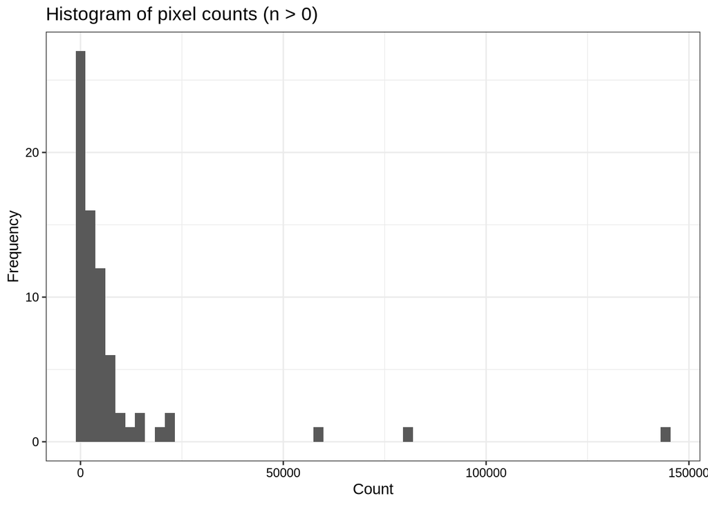

**Figure.** X axis: the pixel count of a single treatment x ecoregion cell. Y axis: how many such cells fall in that count bin (frequency). Cells with zero pixels are excluded, so the distribution describes only combinations that exist in the data. No groupings, colours or facets.

Polygon count table, plotted as histogram, zeroes excluded:

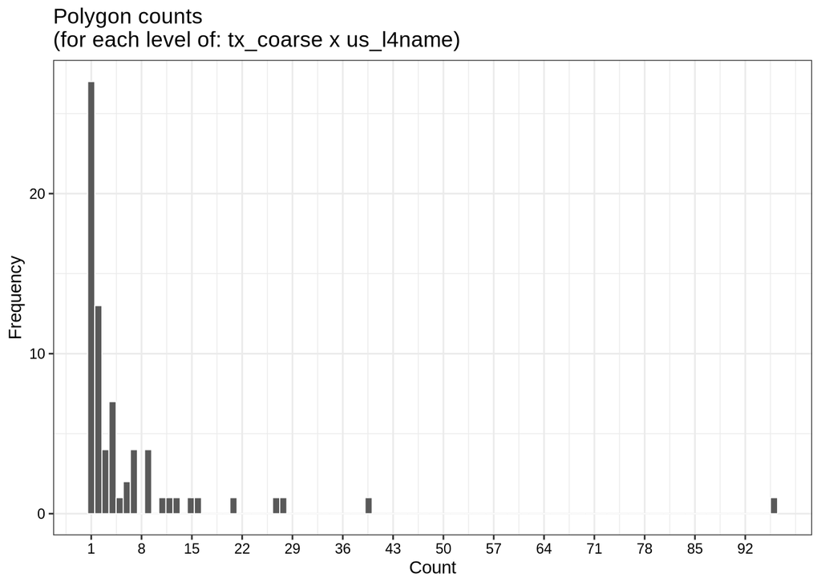

**Figure.** X axis: the number of distinct polygons in a single treatment x ecoregion cell, with one break per integer. Y axis: how many cells have that polygon count (frequency). Zero-polygon cells are excluded. No groupings, colours or facets.

Polygon count table: for each year since treatment, how many distinct polygons contribute at least one pixel that year.

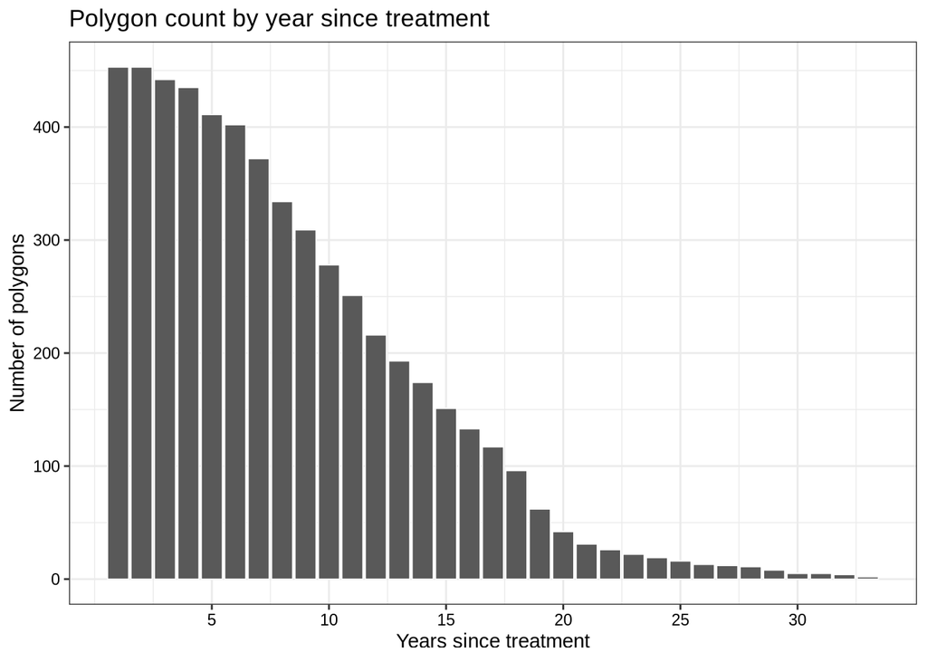

**Figure.** X axis: years since treatment, labelled every 5 years. Y axis: the number of distinct polygons contributing at least one pixel in that year - i.e. how many independent spatial replicates back that year, which is a different quantity from the year’s pixel count. No groupings, colours or facets.

#### Significant DART effects, by covariate

How often a significant effect occurred, first as one rate for the whole objective and then broken apart by fine objective, by treatment and by ecoregion. All of it is cross-sectional - the time dimension is the next subsection - and all of it reports the *intended* effect, since every level on these axes shares this objective’s management goal.

##### How many pixels have a significant DART result?

DART results are considered significant if the confidence intervals for each DART estimate do not include zero.

| Objective | Cover | Total Pixels | % Significant | % Significant Positive | % Significant Negative |
| --- | --- | --- | --- | --- | --- |
| decrease_tre | TRE | 556499 | 30.2 | 4.6 | 25.6 |

**Table.** One row for this objective x cover response: the total pixel count, the share of those pixels with a significant DART result, and that share split by the raw sign of the effect. The two directional columns sum to the overall column up to rounding. For decrease_tre, a negative effect is the *intended* one (see the terminology section above), so the “% Significant Negative” column is the intended result and the other is unintended.

The same total expressed as intended versus unintended rather than as raw sign: 30.2% of all DART pixels were significant, with the treatment producing the intended (negative) effect in 25.6% of pixels and an unintended (positive) effect in 4.6% of pixels, relative to the assigned objective.

##### How do DART significance patterns change

| Objective (Fine) | Total Pixels | Significant Intended Pixels | % Significant Intended |
| --- | --- | --- | --- |
| increase_pfg, increase_afg, decrease_tre | 9 | 8 | 88.89 |
| increase_pfg, decrease_shr, decrease_tre, null_afg | 2756 | 1873 | 67.96 |
| increase_pfg, increase_shr, decrease_tre, decrease_afg | 11517 | 7814 | 67.85 |
| increase_pfg, decrease_tre, null_afg | 2323 | 1254 | 53.98 |
| increase_pfg, increase_shr, increase_afg, decrease_tre | 12110 | 6311 | 52.11 |
| increase_pfg, decrease_tre, decrease_afg | 350 | 175 | 50.00 |
| increase_shr, decrease_tre, null_afg | 352 | 150 | 42.61 |
| increase_pfg, decrease_tre | 43654 | 15067 | 34.51 |
| increase_pfg, increase_shr, decrease_tre, null_afg | 8794 | 2888 | 32.84 |
| increase_pfg, increase_shr, decrease_tre | 86330 | 28288 | 32.77 |
| increase_shr, decrease_tre | 15682 | 4481 | 28.57 |
| decrease_tre, decrease_shr | 372 | 91 | 24.46 |
| decrease_tre | 212111 | 51452 | 24.26 |
| decrease_tre, null_afg | 9672 | 2011 | 20.79 |
| decrease_shr, decrease_tre | 19165 | 3885 | 20.27 |
| increase_pfg, increase_afg, decrease_shr, decrease_tre | 100 | 20 | 20.00 |
| increase_pfg, decrease_shr, decrease_tre | 130607 | 16664 | 12.76 |
| increase_shr, decrease_afg, decrease_tre | 468 | 59 | 12.61 |
| decrease_tre, decrease_afg | 77 | 8 | 10.39 |
| increase_pfg, decrease_afg, decrease_tre | 50 | 0 | 0.00 |

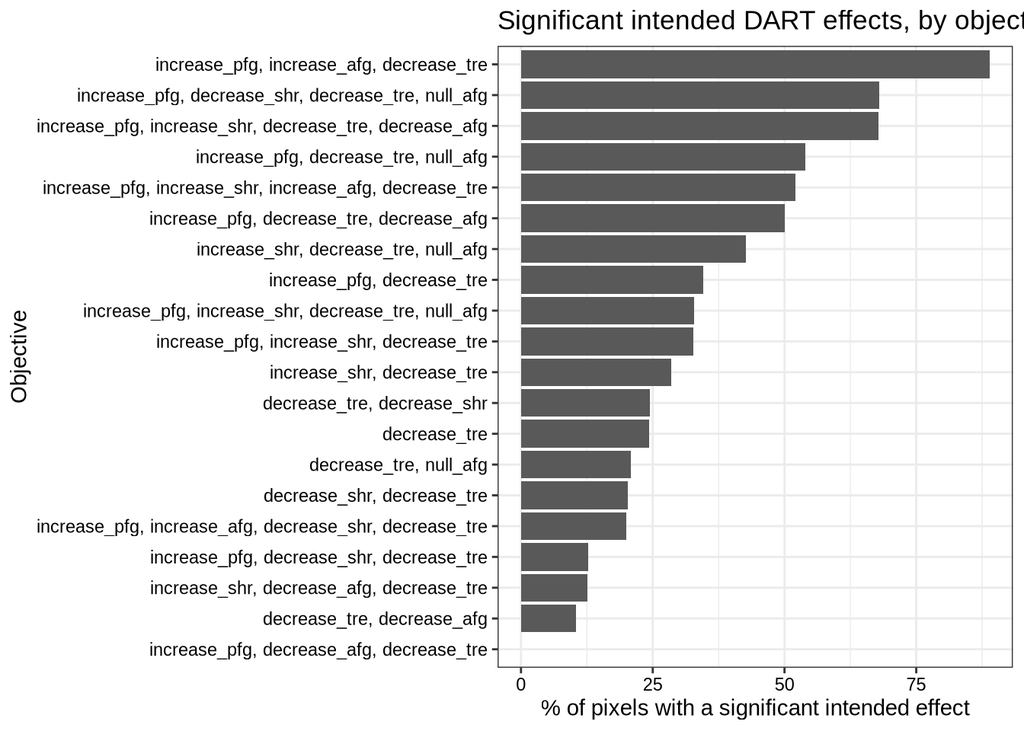

**Table and figure.** One row (and one bar) per *fine* objective string - the full comma-separated objective assignment of a pixel, so a pixel with compound objectives appears under its own combination rather than under each part. X axis of the figure: the percentage of that objective’s pixels with a significant *intended* effect - i.e. significant and in the direction decrease_tre was aiming for, which for this objective is a negative effect. Y axis: the fine objective, ordered by that percentage. Bars are a single grey fill; no colour grouping or facets. Across the 20 fine objectives present, the rate ranges from 0.00% to 88.89%. Because the sign is taken relative to this objective’s goal, these percentages are comparable *within* this section but not against another objective’s version of the same figure - the cross-objective tables at the end of the report use the raw sign for that reason.

Repeated for treatment:

| Treatment | Total Pixels | Significant Intended Pixels | % Significant Intended |
| --- | --- | --- | --- |
| seeding;vegetation removal | 38108 | 19602 | 51.44 |
| seeding;soil disturbance;vegetation removal | 14363 | 7117 | 49.55 |
| seeding;soil disturbance | 57506 | 26841 | 46.68 |
| soil disturbance;vegetation removal | 12558 | 5759 | 45.86 |
| soil disturbance | 11567 | 4349 | 37.60 |
| prescribed burn;seeding | 14641 | 5031 | 34.36 |
| prescribed burn;soil disturbance;vegetation removal | 9846 | 2320 | 23.56 |
| vegetation removal | 218327 | 49966 | 22.89 |
| prescribed burn;vegetation removal | 21150 | 3131 | 14.80 |
| seeding | 2434 | 322 | 13.23 |
| prescribed burn | 154865 | 17942 | 11.59 |
| prescribed burn;seeding;soil disturbance;vegetation removal | 1059 | 119 | 11.24 |
| prescribed burn;seeding;soil disturbance | 75 | 0 | 0.00 |

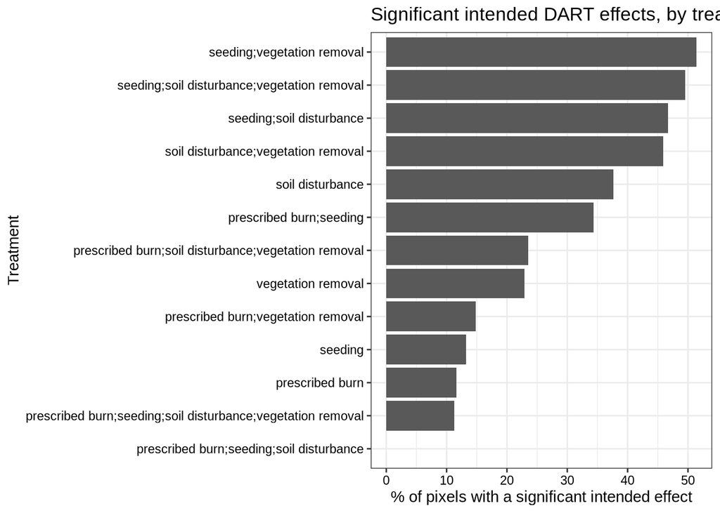

**Table and figure.** As above, grouped by coarse treatment (`'tx_coarse'`). X axis: % of that treatment’s pixels with a significant *intended* (negative) effect. Y axis: treatment, ordered by that percentage. Single grey fill, no facets. Range across the 13 treatments: 0.00% to 51.44%. This is the closest thing in the report to a per-treatment success rate for this objective, since the direction counted is the one the treatment was trying to produce.

Lastly, for ecoregion:

| Ecoregion | Total Pixels | Significant Intended Pixels | % Significant Intended |
| --- | --- | --- | --- |
| High Elevation Forests and Shrublands | 16 | 16 | 100.00 |
| Dissected High Lava Plateau | 13633 | 6036 | 44.27 |
| Sagebrush Basins and Slopes | 56163 | 20701 | 36.86 |
| Northern Uinta Basin Slopes | 5841 | 2108 | 36.09 |
| Woodland- and Shrub-Covered Low Mountains | 59901 | 19937 | 33.28 |
| Semiarid Foothills | 108892 | 33483 | 30.75 |
| Escarpments | 12701 | 3212 | 25.29 |
| Semiarid Hills and Low Mountains | 4626 | 1107 | 23.93 |
| Wasatch Montane Zone | 7572 | 1666 | 22.00 |
| Foothill Shrublands and Low Mountains | 7687 | 1648 | 21.44 |
| Semiarid Benchlands and Canyonlands | 265245 | 51132 | 19.28 |
| Mountain Valleys | 3272 | 393 | 12.01 |
| Mid-Elevation Uinta Mountains | 3339 | 383 | 11.47 |
| Rolling Sagebrush Steppe | 7401 | 662 | 8.94 |
| Crystalline Mid-Elevation Forests | 210 | 15 | 7.14 |

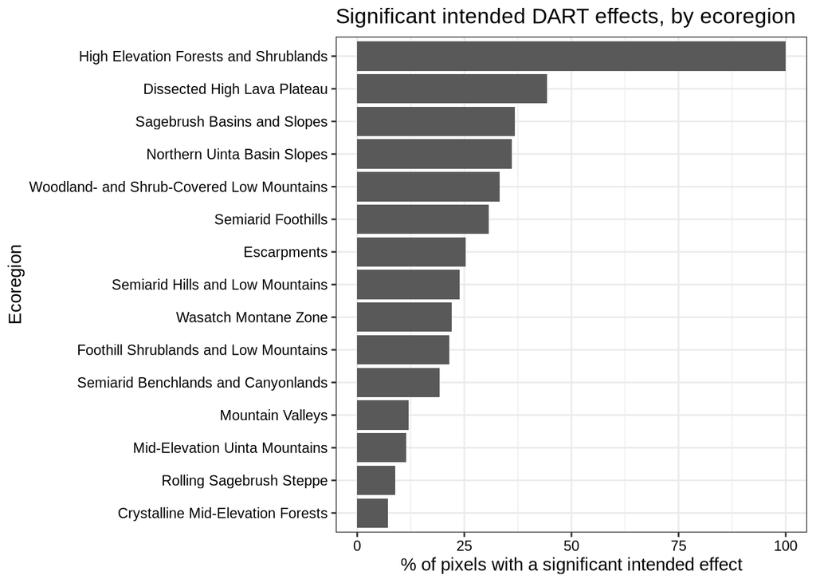

**Table and figure.** As above, grouped by level-IV ecoregion (`'us_l4name'`). X axis: % of that ecoregion’s pixels with a significant *intended* (negative) effect. Y axis: ecoregion, ordered by that percentage. Single grey fill, no facets. Range across the 15 ecoregions: 7.14% to 100.00%.

#### Significant DART effects, through time

The same effects along the time axis and against the covariates that interact with it: how often a significant effect occurred in each year since treatment, how large those effects were and when they peaked, and how the per-polygon peak years distribute across treatments and ecoregions. Read the two halves as separate questions - a year can carry a high significance rate with small effects, or the reverse.

##### How does time since treatment affect significance?

This section attempts to answer two questions:

1. How *often* does a significant effect show up in a given year? The stacked-direction figure immediately below.
2. How *large* are those effects? The mean-effect table and figure further down. A year can have a handful of significant pixels that each moved a long way, or many pixels that each moved a little, and those are different results.

No weighting is used anywhere in this section. The mean effect per year is a plain arithmetic mean of `effect` over the significant pixels in that year, split by direction of effect, so the reported peak is the year whose significant pixels actually moved furthest rather than a significance-weighted compromise across the whole time series. Some weighting methods were checked and did not improve the results - see `weight_testing_summary.Rmd` for that analysis.

Everything in this section is drawn on the **truncated** series: for this objective no year fell below the 10-significant-pixel threshold, so the full record to year 33 is used. This is what stops a peak year being reported from the part of the record where almost nothing was significant; it also means the x axis here can end earlier than another objective’s, so the two are not read off the same range.

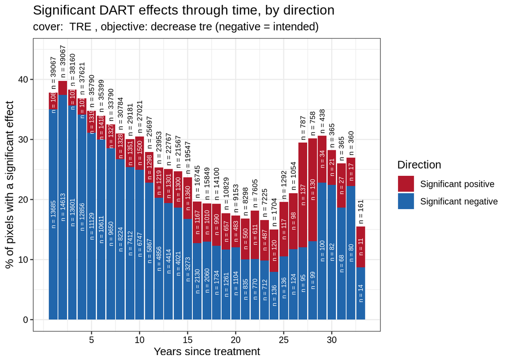

**Figure.** X axis: years since treatment, one bar per year, labelled every 5 years. Y axis: the percentage of that year’s pixels with a significant DART effect - the full height of a bar is the year’s overall % significant, and it is a percentage of all pixels observed in that year, not of the significant ones. Fill: the direction of the significant effect, splitting each bar into a blue *significant negative* component and a red *significant positive* component; the intended direction for this objective (negative) is the segment drawn against the axis, with the unintended direction stacked above it. Fill colours mean the same thing in every direction figure in this report. There are no facets or other groupings.

Two different sample sizes are labelled on each bar, and they are **not** meant to sum to each other:

- The rotated label sitting *above* each bar is that year’s **group total** - every pixel observed in that year, significant or not. It says how much data is behind the bar, and it is the denominator of the percentage on the Y axis.
- The white label *inside* each stacked segment is the number of pixels that were significant **and** in that segment’s direction. These two are the sample sizes behind the two segment heights themselves.

So the two segment labels add up to the number of *significant* pixels in that year, which is generally far smaller than the group total above the bar, because most pixels in a year are not significant. Reading down a tall bar with a small group total is therefore a different situation from a short bar with a large one, which is exactly why both numbers are drawn. Segments too short to hold their label legibly are left unlabelled to avoid white text spilling onto the panel background.

- Treatment was **most** effective (highest % significant pixels) at year 2 (39.7% significant).
- Treatment was **least** effective (lowest % significant pixels) at year 24 (15.0% significant).

##### How large were the significant effects in each year?

The figure below switches from counting significant pixels to measuring them: among significant pixels only, what was the mean DART effect in each year since treatment, and in which year was that mean largest? Positive and negative effects are summarized separately throughout.

| Direction | Peak Year | Mean Effect at Peak | SE | Significant Pixels at Peak | Last Year Observed | Peak Censored? |
| --- | --- | --- | --- | --- | --- | --- |
| negative | 29 | -26.6402 | 1.0229 | 100 | 33 | FALSE |
| positive | 31 | 14.2400 | 1.2612 | 27 | 33 | FALSE |

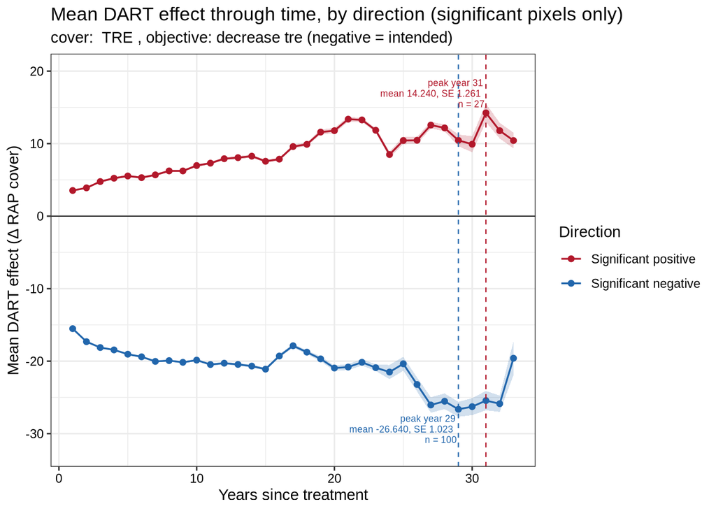

**Table.** One row per direction of effect: the year in which the mean effect over significant pixels was largest in magnitude, that mean, its SE, the number of significant pixels behind it, the last year observed for that direction, and whether the peak is censored (lands on that last year).

**Figure.** X axis: years since treatment. Y axis: the mean DART effect (Δ RAP cover) among *significant pixels only* in that year, computed separately for each direction - so the two series sit either side of the zero line by construction and are never averaged into a single number. Colour: direction of the effect (red = significant positive, blue = significant negative), using the same colours as the stacked figure above. The shaded band around each line is that year × direction mean ± 1 SE: it is sampling uncertainty in the *mean* effect, not the spread of individual pixel effects, so it narrows mainly where a year has many significant pixels. A year × direction cell backed by a single significant pixel has no SE and is drawn as a bare point, keeping the line through it unbroken. Dashed vertical lines mark each direction’s peak year from the table above, labelled with the mean effect at the peak, its SE, and the number of significant pixels behind it. Non-significant pixels are excluded outright rather than entered as zeros, and no weighting is applied anywhere. There are no facets or other groupings.

- Significant **negative** effects were largest at year 29 (mean effect -26.6402, SE 1.0229, n = 100 significant pixels).
- Significant **positive** effects were largest at year 31 (mean effect 14.2400, SE 1.2612, n = 27 significant pixels).

Note that the year with the largest mean effect need not be the year with the most significant pixels: the two questions can peak at different times, and a peak that lands on the last observed year is flagged as censored above for the same reason as in the by-polygon table further down.

| Objective | Cover | Year Bin | Total Pixels | Mean % Significant | Mean % Significant Positive | Mean % Significant Negative |
| --- | --- | --- | --- | --- | --- | --- |
| decrease_tre | TRE | 1-5 | 189705 | 37.55 | 2.82 | 34.73 |
| decrease_tre | TRE | 6-10 | 156175 | 31.74 | 4.43 | 27.31 |
| decrease_tre | TRE | 11-15 | 113531 | 25.46 | 5.71 | 19.76 |
| decrease_tre | TRE | 16+ | 97088 | 18.76 | 6.88 | 11.89 |

**Table.** The same significance rates as the year-by-year figure, collapsed into 1-5, 6-10, 11-15 and 16+ years since treatment. One row per bin; percentages are of all pixels in that bin, and the two directional columns sum to the overall column up to rounding.

| Treatment | N Polygons | Mean Year of Peak Sig. | SD | Min | Max | % Censored (peak at last obs. year) |
| --- | --- | --- | --- | --- | --- | --- |
| prescribed burn | 13 | 8.46 | 8.35 | 1 | 27 | 0.0 |
| prescribed burn;seeding | 5 | 4.80 | 5.76 | 1 | 15 | 20.0 |
| prescribed burn;seeding;soil disturbance | 1 | 1.00 |  | 1 | 1 | 0.0 |
| prescribed burn;seeding;soil disturbance;vegetation removal | 3 | 1.67 | 1.15 | 1 | 3 | 0.0 |
| prescribed burn;soil disturbance;vegetation removal | 2 | 2.00 | 0.00 | 2 | 2 | 0.0 |
| prescribed burn;vegetation removal | 9 | 2.56 | 2.51 | 1 | 9 | 11.1 |
| seeding | 6 | 3.00 | 2.28 | 1 | 6 | 0.0 |
| seeding;soil disturbance | 61 | 3.20 | 3.20 | 1 | 18 | 3.3 |
| seeding;soil disturbance;vegetation removal | 23 | 2.52 | 1.90 | 1 | 9 | 0.0 |
| seeding;vegetation removal | 75 | 2.92 | 3.77 | 1 | 23 | 4.0 |
| soil disturbance | 11 | 5.09 | 6.30 | 1 | 18 | 0.0 |
| soil disturbance;vegetation removal | 12 | 3.00 | 2.98 | 1 | 10 | 0.0 |
| vegetation removal | 232 | 4.19 | 4.51 | 1 | 28 | 5.2 |

| Ecoregion | N Polygons | Mean Year of Peak Sig. | SD | Min | Max | % Censored (peak at last obs. year) |
| --- | --- | --- | --- | --- | --- | --- |
| Crystalline Mid-Elevation Forests | 2 | 1.50 | 0.71 | 1 | 2 | 0.0 |
| Dissected High Lava Plateau | 12 | 2.83 | 3.04 | 1 | 12 | 0.0 |
| Escarpments | 13 | 3.31 | 5.09 | 1 | 20 | 7.7 |
| Foothill Shrublands and Low Mountains | 10 | 5.30 | 5.17 | 1 | 16 | 10.0 |
| High Elevation Forests and Shrublands | 1 | 1.00 |  | 1 | 1 | 0.0 |
| Mid-Elevation Uinta Mountains | 9 | 2.89 | 2.20 | 1 | 6 | 11.1 |
| Mountain Valleys | 8 | 5.00 | 4.00 | 1 | 13 | 12.5 |
| Northern Uinta Basin Slopes | 11 | 4.09 | 3.21 | 1 | 10 | 0.0 |
| Rolling Sagebrush Steppe | 7 | 8.29 | 6.21 | 1 | 16 | 0.0 |
| Sagebrush Basins and Slopes | 48 | 3.33 | 2.96 | 1 | 13 | 4.2 |
| Semiarid Benchlands and Canyonlands | 169 | 3.82 | 4.42 | 1 | 22 | 3.0 |
| Semiarid Foothills | 82 | 3.45 | 3.50 | 1 | 19 | 6.1 |
| Semiarid Hills and Low Mountains | 6 | 6.83 | 8.50 | 1 | 23 | 16.7 |
| Wasatch Montane Zone | 9 | 2.67 | 2.00 | 1 | 6 | 0.0 |
| Woodland- and Shrub-Covered Low Mountains | 66 | 3.98 | 5.53 | 1 | 28 | 3.0 |

**Tables.** Each polygon is reduced to the single year in which its own % significant pixels was highest (“peak significance year”); those per-polygon peak years are then summarized across polygons, by treatment in the first table and by ecoregion in the second. Columns: number of polygons behind the row, mean / SD / min / max of the peak year, and the percentage of polygons whose peak fell on the last year they were observed. A polygon’s peak year is flagged as “censored” in those cases, because we can’t rule out that significance was still rising beyond the end of the available time series. Note that “last year observed” now means the last year *retained* after the late-year truncation described above, so where a series was truncated the censoring flag is partly an artefact of the threshold rather than of the record itself - it marks the end of the analysable series, not necessarily the end of the data. What that censoring implies is taken up under *Interpretation* at the end of the report.

#### Overall results and interpretation

##### Summary statistics

What the three sample-size filters cost this objective x cover response, in one row - the same quantities reported in prose under *Results after dropping* above, gathered here so that this subsection stands on its own. The identical row appears in the cross-objective filtering log in `2_make_DART_results.Rmd`, where it can be read against the other objectives.

| Objective | Cover | Min Pixels per Tx x Eco | # Tx x Eco Excluded | # Tx Depopulated | # Eco Depopulated | Min Pixels per Year | Year Truncated At | # Years Dropped | % Pixels Lost | # Tx Absent | # Eco Absent |
| --- | --- | --- | --- | --- | --- | --- | --- | --- | --- | --- | --- |
| decrease_tre | TRE | 10 | 0 | 0 | 0 | 10 | NA | 0 | 0 | 0 | 0 |

**Table.** One row for this objective x cover response. `% Pixels Lost` is the combined cost of all three filters, not the cell filter alone. `# Tx Absent` / `# Eco Absent` count levels missing from the post-filter data for any reason, which is a different quantity from the two depopulated columns: a level that only ever appeared in sparse cells disappears without the depopulation filter being involved.

Post-filter, this objective x cover response retains 556499 pixels across 13 treatment level(s) and 15 ecoregion level(s), the smallest surviving totals being 75 pixels for a treatment and 16 for an ecoregion, against a per-cell threshold of 10.

### cover: PFG , objective: increase pfg

#### Sample sizes and scope

How much data backs this objective x cover response, how much of it the three sample-size filters removed, and how much of it is shared with other objectives. Everything here is descriptive: no treatment effect is reported in this subsection. Pixel counts are shown per treatment x ecoregion cell, which is the unit the first filter works on, and then again per treatment and per ecoregion *after* filtering - the pre-filter totals by treatment and by ecoregion were dropped as unhelpful, since nothing downstream is built on them.

##### Pixel counts for each treatment × ecoregion combination (`'tx_coarse'` x `'us_l4name'`)

Each level of (treatment x ecoregion) is filtered here for low sample size (300 pixels).

|  | Arid Canyonlands | Crystalline Mid-Elevation Forests | Dissected High Lava Plateau | Eastern Mojave Basins | Eastern Mojave Low Ranges and Arid Footslopes | Eastern Mojave Mountain Woodland and Shrubland | Escarpments | Foothill Shrublands and Low Mountains | High Elevation Carbonate Mountains | High Elevation Forests and Shrublands | High Plateaus | Malad and Cache Valleys | Mid-Elevation Uinta Mountains | Monticello-Cortez Uplands | Mountain Valleys | Northern Uinta Basin Slopes | Rolling Sagebrush Steppe | Sagebrush Basins and Slopes | Semiarid Benchlands and Canyonlands | Semiarid Foothills | Semiarid Hills and Low Mountains | Shadscale-Dominated Saline Basins | Shale Deserts and Sedimentary Basins | Sub-Irrigated High Valleys | Uinta Basin Floor | Wasatch Montane Zone | Wetlands | Woodland- and Shrub-Covered Low Mountains |
| --- | --- | --- | --- | --- | --- | --- | --- | --- | --- | --- | --- | --- | --- | --- | --- | --- | --- | --- | --- | --- | --- | --- | --- | --- | --- | --- | --- | --- |
| prescribed burn | 0 | 0 | 0 | 0 | 0 | 0 | 4159 | 0 | 0 | 0 | 0 | 0 | 0 | 0 | 0 | 0 | 0 | 1764 | 142533 | 0 | 0 | 0 | 0 | 0 | 0 | 0 | 0 | 6576 |
| prescribed burn;seeding | 0 | 0 | 0 | 0 | 0 | 0 | 1008 | 0 | 0 | 0 | 0 | 16 | 0 | 0 | 124 | 0 | 0 | 16896 | 5056 | 1890 | 0 | 0 | 0 | 0 | 0 | 30 | 0 | 6696 |
| prescribed burn;seeding;soil disturbance | 0 | 0 | 0 | 0 | 0 | 0 | 0 | 120 | 0 | 0 | 0 | 224 | 0 | 0 | 0 | 0 | 0 | 0 | 75 | 0 | 0 | 0 | 0 | 0 | 0 | 0 | 0 | 0 |
| prescribed burn;seeding;soil disturbance;vegetation removal | 0 | 0 | 0 | 0 | 0 | 0 | 0 | 0 | 0 | 0 | 0 | 0 | 0 | 0 | 0 | 0 | 0 | 304 | 731 | 0 | 0 | 0 | 0 | 0 | 0 | 0 | 0 | 0 |
| prescribed burn;soil disturbance | 0 | 0 | 0 | 0 | 0 | 0 | 0 | 0 | 0 | 0 | 0 | 0 | 0 | 0 | 0 | 0 | 0 | 0 | 0 | 2205 | 0 | 0 | 0 | 0 | 0 | 0 | 0 | 0 |
| prescribed burn;vegetation removal | 0 | 0 | 0 | 0 | 0 | 0 | 0 | 0 | 0 | 0 | 0 | 0 | 0 | 0 | 0 | 0 | 0 | 0 | 0 | 2150 | 0 | 0 | 0 | 0 | 0 | 0 | 0 | 1248 |
| seeding | 0 | 451 | 6712 | 576 | 0 | 3369 | 1656 | 29166 | 1974 | 0 | 680 | 0 | 0 | 650 | 387 | 2034 | 0 | 16926 | 21413 | 4965 | 1929 | 1822 | 351 | 295 | 0 | 0 | 0 | 19479 |
| seeding;soil disturbance | 168 | 0 | 5833 | 0 | 0 | 0 | 0 | 3480 | 0 | 24 | 4096 | 180 | 0 | 866 | 30741 | 638 | 0 | 36904 | 23315 | 26667 | 1290 | 5063 | 0 | 0 | 0 | 1470 | 0 | 24758 |
| seeding;soil disturbance;vegetation removal | 0 | 0 | 100 | 0 | 0 | 0 | 612 | 0 | 0 | 0 | 0 | 39 | 0 | 0 | 505 | 54 | 855 | 4398 | 4759 | 4470 | 0 | 3750 | 0 | 0 | 1574 | 0 | 65 | 7651 |
| seeding;vegetation removal | 0 | 0 | 4567 | 0 | 0 | 0 | 1547 | 252 | 0 | 0 | 0 | 484 | 84 | 0 | 263 | 0 | 313 | 4491 | 12446 | 3767 | 2758 | 384 | 3978 | 0 | 132 | 0 | 8 | 10147 |
| soil disturbance | 0 | 0 | 0 | 0 | 65 | 0 | 0 | 0 | 0 | 0 | 0 | 0 | 0 | 1512 | 851 | 0 | 0 | 374 | 1629 | 1211 | 0 | 0 | 0 | 0 | 0 | 0 | 0 | 0 |
| soil disturbance;vegetation removal | 0 | 0 | 0 | 0 | 0 | 0 | 0 | 1944 | 0 | 0 | 0 | 0 | 40 | 308 | 0 | 0 | 0 | 192 | 1044 | 2302 | 0 | 0 | 0 | 0 | 0 | 0 | 6 | 474 |
| vegetation removal | 0 | 570 | 0 | 0 | 0 | 0 | 307 | 0 | 0 | 0 | 0 | 188 | 28 | 0 | 0 | 1704 | 110 | 18970 | 16517 | 5467 | 0 | 0 | 0 | 0 | 18 | 1350 | 0 | 3079 |

|  | Arid Canyonlands | Dissected High Lava Plateau | Eastern Mojave Low Ranges and Arid Footslopes | Foothill Shrublands and Low Mountains | High Elevation Forests and Shrublands | Malad and Cache Valleys | Mid-Elevation Uinta Mountains | Mountain Valleys | Northern Uinta Basin Slopes | Rolling Sagebrush Steppe | Sagebrush Basins and Slopes | Semiarid Benchlands and Canyonlands | Sub-Irrigated High Valleys | Uinta Basin Floor | Wasatch Montane Zone | Wetlands |
| --- | --- | --- | --- | --- | --- | --- | --- | --- | --- | --- | --- | --- | --- | --- | --- | --- |
| prescribed burn;seeding |  |  |  |  |  | 16 |  | 124 |  |  |  |  |  |  | 30 |  |
| prescribed burn;seeding;soil disturbance |  |  |  | 120 |  | 224 |  |  |  |  |  | 75 |  |  |  |  |
| seeding |  |  |  |  |  |  |  |  |  |  |  |  | 295 |  |  |  |
| seeding;soil disturbance | 168 |  |  |  | 24 | 180 |  |  |  |  |  |  |  |  |  |  |
| seeding;soil disturbance;vegetation removal |  | 100 |  |  |  | 39 |  |  | 54 |  |  |  |  |  |  | 65 |
| seeding;vegetation removal |  |  |  | 252 |  |  | 84 | 263 |  |  |  |  |  | 132 |  | 8 |
| soil disturbance |  |  | 65 |  |  |  |  |  |  |  |  |  |  |  |  |  |
| soil disturbance;vegetation removal |  |  |  |  |  |  | 40 |  |  |  | 192 |  |  |  |  | 6 |
| vegetation removal |  |  |  |  |  | 188 | 28 |  |  | 110 |  |  |  | 18 |  |  |

**Table.** The first table is the full pixel count for every treatment (rows) x ecoregion (columns) combination; the second keeps only the cells that are non-zero but below the 300-pixel threshold, i.e. the combinations that are present but too sparse to analyse. Empty cells in the second table are combinations that are either absent or above the threshold.

| Treatment | Ecoregion |
| --- | --- |
| seeding;soil disturbance | Arid Canyonlands |
| seeding;soil disturbance;vegetation removal | Dissected High Lava Plateau |
| soil disturbance | Eastern Mojave Low Ranges and Arid Footslopes |
| prescribed burn;seeding;soil disturbance | Foothill Shrublands and Low Mountains |
| seeding;vegetation removal | Foothill Shrublands and Low Mountains |
| seeding;soil disturbance | High Elevation Forests and Shrublands |
| prescribed burn;seeding | Malad and Cache Valleys |
| prescribed burn;seeding;soil disturbance | Malad and Cache Valleys |
| seeding;soil disturbance | Malad and Cache Valleys |
| seeding;soil disturbance;vegetation removal | Malad and Cache Valleys |
| vegetation removal | Malad and Cache Valleys |
| seeding;vegetation removal | Mid-Elevation Uinta Mountains |
| soil disturbance;vegetation removal | Mid-Elevation Uinta Mountains |
| vegetation removal | Mid-Elevation Uinta Mountains |
| prescribed burn;seeding | Mountain Valleys |
| seeding;vegetation removal | Mountain Valleys |
| seeding;soil disturbance;vegetation removal | Northern Uinta Basin Slopes |
| vegetation removal | Rolling Sagebrush Steppe |
| soil disturbance;vegetation removal | Sagebrush Basins and Slopes |
| prescribed burn;seeding;soil disturbance | Semiarid Benchlands and Canyonlands |
| seeding | Sub-Irrigated High Valleys |
| seeding;vegetation removal | Uinta Basin Floor |
| vegetation removal | Uinta Basin Floor |
| prescribed burn;seeding | Wasatch Montane Zone |
| seeding;soil disturbance;vegetation removal | Wetlands |
| seeding;vegetation removal | Wetlands |
| soil disturbance;vegetation removal | Wetlands |

**Table.** 27 treatment x ecoregion combinations fall below the 300-pixel threshold, representing 0.48% of the total sample size for this objective x cover response. Each row is one combination that will be dropped below.

**Are these sparse combinations especially significant (or non-significant)?**

| Treatment | Ecoregion | Significant Pixels | Total Pixels | % Significant Pixels |
| --- | --- | --- | --- | --- |
| prescribed burn;seeding | Malad and Cache Valleys | 0 | 16 | 0.00 |
| prescribed burn;seeding | Mountain Valleys | 69 | 124 | 55.65 |
| prescribed burn;seeding | Wasatch Montane Zone | 11 | 30 | 36.67 |
| prescribed burn;seeding;soil disturbance | Foothill Shrublands and Low Mountains | 2 | 120 | 1.67 |
| prescribed burn;seeding;soil disturbance | Malad and Cache Valleys | 9 | 224 | 4.02 |
| prescribed burn;seeding;soil disturbance | Semiarid Benchlands and Canyonlands | 6 | 75 | 8.00 |
| seeding | Sub-Irrigated High Valleys | 66 | 295 | 22.37 |
| seeding;soil disturbance | Arid Canyonlands | 66 | 168 | 39.29 |
| seeding;soil disturbance | High Elevation Forests and Shrublands | 23 | 24 | 95.83 |
| seeding;soil disturbance | Malad and Cache Valleys | 45 | 180 | 25.00 |
| seeding;soil disturbance;vegetation removal | Dissected High Lava Plateau | 15 | 100 | 15.00 |
| seeding;soil disturbance;vegetation removal | Malad and Cache Valleys | 6 | 39 | 15.38 |
| seeding;soil disturbance;vegetation removal | Northern Uinta Basin Slopes | 17 | 54 | 31.48 |
| seeding;soil disturbance;vegetation removal | Wetlands | 31 | 65 | 47.69 |
| seeding;vegetation removal | Foothill Shrublands and Low Mountains | 250 | 252 | 99.21 |
| seeding;vegetation removal | Mid-Elevation Uinta Mountains | 0 | 84 | 0.00 |
| seeding;vegetation removal | Mountain Valleys | 67 | 263 | 25.48 |
| seeding;vegetation removal | Uinta Basin Floor | 1 | 132 | 0.76 |
| seeding;vegetation removal | Wetlands | 0 | 8 | 0.00 |
| soil disturbance | Eastern Mojave Low Ranges and Arid Footslopes | 50 | 65 | 76.92 |
| soil disturbance;vegetation removal | Mid-Elevation Uinta Mountains | 26 | 40 | 65.00 |
| soil disturbance;vegetation removal | Sagebrush Basins and Slopes | 0 | 192 | 0.00 |
| soil disturbance;vegetation removal | Wetlands | 0 | 6 | 0.00 |
| vegetation removal | Malad and Cache Valleys | 50 | 188 | 26.60 |
| vegetation removal | Mid-Elevation Uinta Mountains | 8 | 28 | 28.57 |
| vegetation removal | Rolling Sagebrush Steppe | 67 | 110 | 60.91 |
| vegetation removal | Uinta Basin Floor | 0 | 18 | 0.00 |

**Table.** Significance rate within the sparse combinations only: one row per dropped treatment x ecoregion combination, giving its significant pixel count, its total pixel count, and the resulting percentage. Compare against the overall rate reported further down to see whether the dropped cells were unusual.

##### Results after dropping (treatment x ecoregion)

The pixel cutoff for each (treatment × ecoregion) combination was 300.

Three filters have now been applied to this objective x cover response, in this order, and the percentage below is the combined cost of all three:

1. **Sparse (treatment x ecoregion) cells** - the 27 combinations listed above, below 300 pixels each.
2. **Depopulated treatment or ecoregion levels** - on, at the same 300-pixel threshold: 0 treatment and 0 ecoregion level(s) removed. This catches a level thinned across many surviving cells, which the cell filter cannot see.
3. **Late-year truncation** - no year fell below 10 significant pixels, so the series was not truncated.

Total data lost across all three: **0.48%**. Treatment levels absent from the post-filter data: `prescribed burn;seeding;soil disturbance`. Ecoregion levels absent: `Eastern Mojave Low Ranges and Arid Footslopes`, `High Elevation Forests and Shrublands`, `Sub-Irrigated High Valleys`, `Mid-Elevation Uinta Mountains`, `Wetlands`, `Arid Canyonlands`. (These are levels gone for *any* reason - a level that only ever appeared in sparse cells disappears without the depopulation filter being involved.)

The post-filter totals below are the check that the three filters together have not left some treatment or ecoregion analysable in name only.

| Treatment | Pixel Count (post-filter) |
| --- | --- |
| prescribed burn | 155032 |
| prescribed burn;seeding | 31546 |
| prescribed burn;seeding;soil disturbance;vegetation removal | 1035 |
| prescribed burn;soil disturbance | 2205 |
| prescribed burn;vegetation removal | 3398 |
| seeding | 114540 |
| seeding;soil disturbance | 165121 |
| seeding;soil disturbance;vegetation removal | 28574 |
| seeding;vegetation removal | 44882 |
| soil disturbance | 5577 |
| soil disturbance;vegetation removal | 6072 |
| vegetation removal | 47964 |

| Ecoregion | Pixel Count (post-filter) |
| --- | --- |
| Crystalline Mid-Elevation Forests | 1021 |
| Dissected High Lava Plateau | 17112 |
| Eastern Mojave Basins | 576 |
| Eastern Mojave Mountain Woodland and Shrubland | 3369 |
| Escarpments | 9289 |
| Foothill Shrublands and Low Mountains | 34590 |
| High Elevation Carbonate Mountains | 1974 |
| High Plateaus | 4776 |
| Malad and Cache Valleys | 484 |
| Monticello-Cortez Uplands | 3336 |
| Mountain Valleys | 32484 |
| Northern Uinta Basin Slopes | 4376 |
| Rolling Sagebrush Steppe | 1168 |
| Sagebrush Basins and Slopes | 101027 |
| Semiarid Benchlands and Canyonlands | 229443 |
| Semiarid Foothills | 55094 |
| Semiarid Hills and Low Mountains | 5977 |
| Shadscale-Dominated Saline Basins | 11019 |
| Shale Deserts and Sedimentary Basins | 4329 |
| Uinta Basin Floor | 1574 |
| Wasatch Montane Zone | 2820 |
| Woodland- and Shrub-Covered Low Mountains | 80108 |

**Tables.** Post-filter pixel totals, by treatment and by ecoregion, after the sparse combinations above were dropped. The smallest surviving treatment total is 1035 pixels and the smallest surviving ecoregion total is 484 pixels, against a combination-level threshold of 300.

##### How often does this objective overlap with other objectives?

| Objective | Cover | Co-occurring Objective | Pixel Count | % of Total Pixels |
| --- | --- | --- | --- | --- |
| increase_pfg | PFG | none | 114791 | 18.94 |
| increase_pfg | PFG | decrease_tre | 296185 | 48.88 |
| increase_pfg | PFG | increase_shr | 254403 | 41.98 |
| increase_pfg | PFG | decrease_shr | 157896 | 26.06 |
| increase_pfg | PFG | decrease_afg | 69232 | 11.43 |
| increase_pfg | PFG | null_afg | 21643 | 3.57 |
| increase_pfg | PFG | increase_afg | 18667 | 3.08 |
| increase_pfg | PFG | increase_tre | 2997 | 0.49 |

**Table.** Among pixels assigned to increase_pfg, how often each *other* objective was also assigned to that same pixel. The first row (`none`) is the pixels that carried no other objective. Percentages are shares of this objective’s own (post-filter) pixel total, so they sum to more than 100% wherever pixels carry more than two objectives.

#### Pixel and polygon counts, post-filtering

Pixel counts per polygon, excluding zeros, *i.e.* no pixels present for that `'tx_coarse'` x `'us_l4name'` combination):

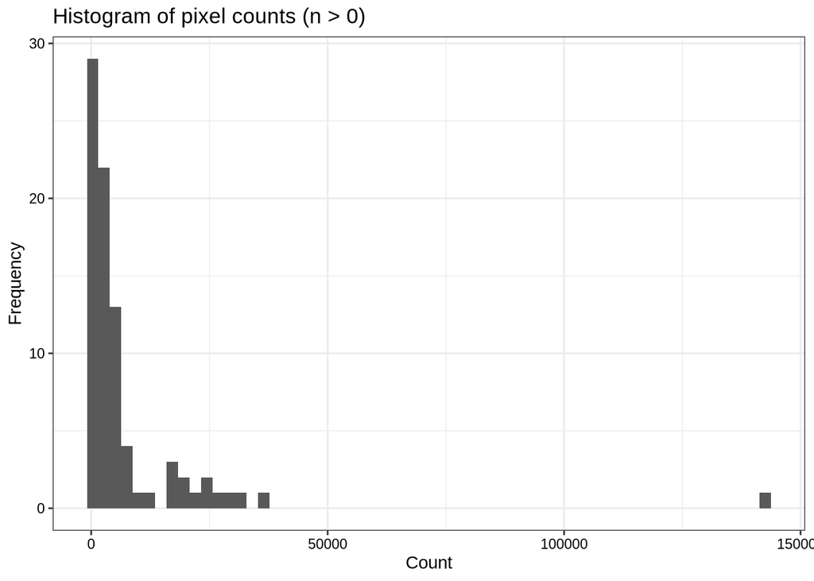

**Figure.** X axis: the pixel count of a single treatment x ecoregion cell. Y axis: how many such cells fall in that count bin (frequency). Cells with zero pixels are excluded, so the distribution describes only combinations that exist in the data. No groupings, colours or facets.

Polygon count table, plotted as histogram, zeroes excluded:

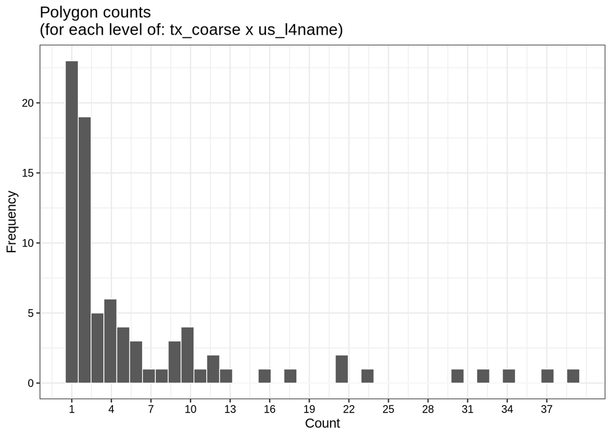

Polygon count table: for each year since treatment, how many distinct polygons contribute at least one pixel that year.

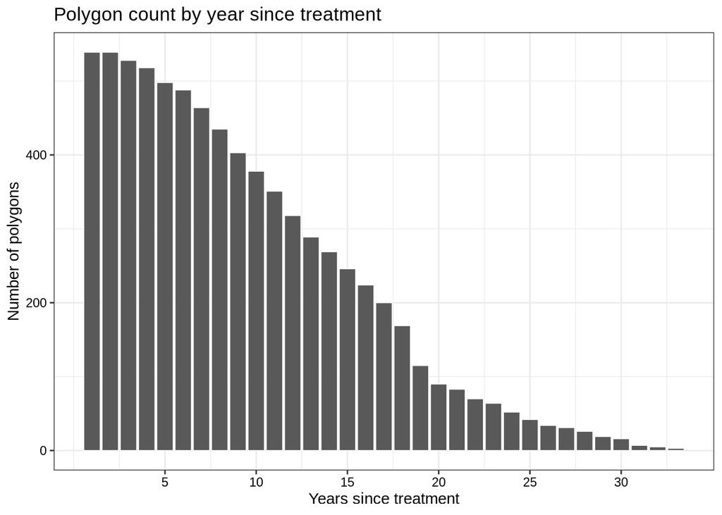

**Figure.** X axis: years since treatment, labelled every 5 years. Y axis: the number of distinct polygons contributing at least one pixel in that year - i.e. how many independent spatial replicates back that year, which is a different quantity from the year’s pixel count. No groupings, colours or facets.

#### Significant DART effects, by covariate

How often a significant effect occurred, first as one rate for the whole objective and then broken apart by fine objective, by treatment and by ecoregion. All of it is cross-sectional - the time dimension is the next subsection - and all of it reports the *intended* effect, since every level on these axes shares this objective’s management goal.

##### How many pixels have a significant DART result?

DART results are considered significant if the confidence intervals for each DART estimate do not include zero.

| Objective | Cover | Total Pixels | % Significant | % Significant Positive | % Significant Negative |
| --- | --- | --- | --- | --- | --- |
| increase_pfg | PFG | 605946 | 24.6 | 20.7 | 3.8 |

**Table.** One row for this objective x cover response: the total pixel count, the share of those pixels with a significant DART result, and that share split by the raw sign of the effect. The two directional columns sum to the overall column up to rounding. For increase_pfg, a positive effect is the *intended* one (see the terminology section above), so the “% Significant Positive” column is the intended result and the other is unintended.

The same total expressed as intended versus unintended rather than as raw sign: 24.6% of all DART pixels were significant, with the treatment producing the intended (positive) effect in 20.7% of pixels and an unintended (negative) effect in 3.8% of pixels, relative to the assigned objective.

##### How do DART significance patterns change

| Objective (Fine) | Total Pixels | Significant Intended Pixels | % Significant Intended |
| --- | --- | --- | --- |
| increase_pfg, decrease_shr, decrease_tre, null_afg | 2731 | 1803 | 66.02 |
| increase_pfg, increase_shr, decrease_tre, decrease_afg | 11271 | 6286 | 55.77 |
| increase_pfg, increase_shr, increase_afg, decrease_tre | 12320 | 5947 | 48.27 |
| increase_pfg, decrease_tre, decrease_afg | 350 | 148 | 42.29 |
| increase_pfg, decrease_tre, null_afg | 2285 | 818 | 35.80 |
| increase_pfg, increase_shr, decrease_tre, null_afg | 8947 | 2791 | 31.19 |
| increase_pfg, increase_shr, decrease_tre | 86165 | 25742 | 29.88 |
| increase_pfg, decrease_tre | 41450 | 12102 | 29.20 |
| increase_pfg, increase_shr, increase_afg | 4564 | 1299 | 28.46 |
| increase_pfg, null_afg | 2877 | 783 | 27.22 |
| increase_pfg, increase_afg, decrease_shr | 501 | 129 | 25.75 |
| increase_pfg, increase_shr, decrease_afg | 23466 | 5657 | 24.11 |
| increase_pfg, decrease_shr, null_afg | 90 | 21 | 23.33 |
| increase_pfg, increase_afg | 1170 | 270 | 23.08 |
| increase_pfg, increase_shr | 100640 | 20069 | 19.94 |
| increase_pfg | 114791 | 20287 | 17.67 |
| increase_pfg, decrease_shr, decrease_afg | 4101 | 640 | 15.61 |
| increase_pfg, decrease_afg | 29989 | 3972 | 13.24 |
| increase_pfg, increase_shr, null_afg | 4713 | 573 | 12.16 |
| increase_pfg, increase_tre | 680 | 82 | 12.06 |
| increase_pfg, decrease_shr, decrease_tre | 130611 | 14725 | 11.27 |
| increase_pfg, increase_shr, increase_tre | 2205 | 203 | 9.21 |
| increase_pfg, decrease_shr | 19862 | 1363 | 6.86 |
| increase_pfg, decrease_afg, decrease_tre | 55 | 1 | 1.82 |
| increase_pfg, increase_shr, increase_afg, increase_tre | 112 | 2 | 1.79 |

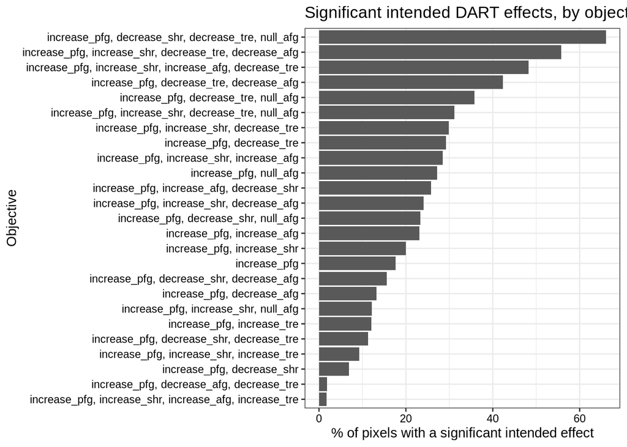

**Table and figure.** One row (and one bar) per *fine* objective string - the full comma-separated objective assignment of a pixel, so a pixel with compound objectives appears under its own combination rather than under each part. X axis of the figure: the percentage of that objective’s pixels with a significant *intended* effect - i.e. significant and in the direction increase_pfg was aiming for, which for this objective is a positive effect. Y axis: the fine objective, ordered by that percentage. Bars are a single grey fill; no colour grouping or facets. Across the 25 fine objectives present, the rate ranges from 1.79% to 66.02%. Because the sign is taken relative to this objective’s goal, these percentages are comparable *within* this section but not against another objective’s version of the same figure - the cross-objective tables at the end of the report use the raw sign for that reason.

Repeated for treatment:

| Treatment | Total Pixels | Significant Intended Pixels | % Significant Intended |
| --- | --- | --- | --- |
| seeding;vegetation removal | 44882 | 17928 | 39.94 |
| seeding;soil disturbance;vegetation removal | 28574 | 9932 | 34.76 |
| prescribed burn;vegetation removal | 3398 | 1079 | 31.75 |
| soil disturbance;vegetation removal | 6072 | 1897 | 31.24 |
| seeding;soil disturbance | 165121 | 47101 | 28.53 |
| soil disturbance | 5577 | 1483 | 26.59 |
| seeding | 114540 | 22278 | 19.45 |
| prescribed burn;seeding;soil disturbance;vegetation removal | 1035 | 129 | 12.46 |
| vegetation removal | 47964 | 5729 | 11.94 |
| prescribed burn | 155032 | 15033 | 9.70 |
| prescribed burn;seeding | 31546 | 2921 | 9.26 |
| prescribed burn;soil disturbance | 2205 | 203 | 9.21 |

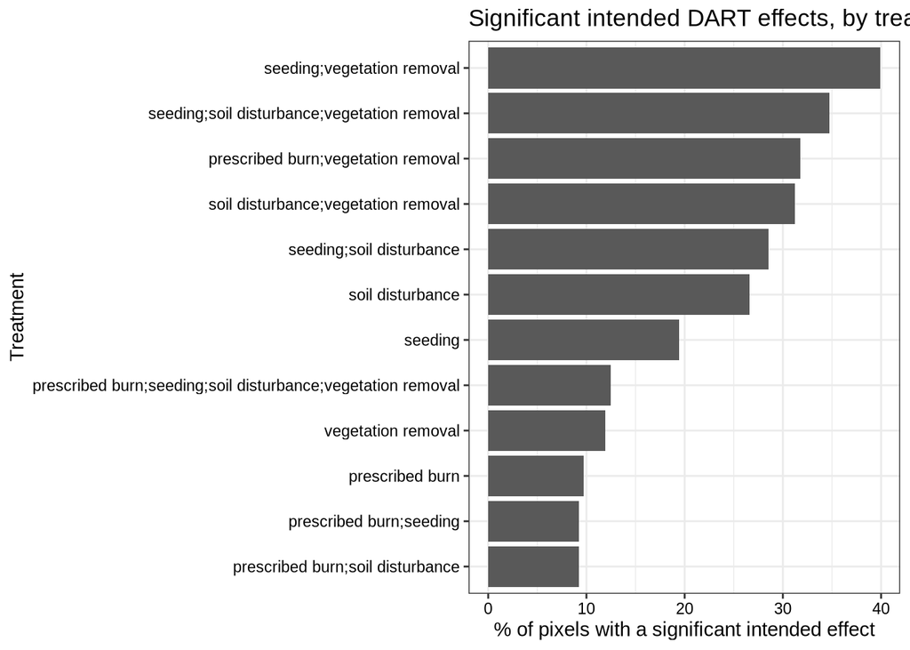

**Table and figure.** As above, grouped by coarse treatment (`'tx_coarse'`). X axis: % of that treatment’s pixels with a significant *intended* (positive) effect. Y axis: treatment, ordered by that percentage. Single grey fill, no facets. Range across the 12 treatments: 9.21% to 39.94%. This is the closest thing in the report to a per-treatment success rate for this objective, since the direction counted is the one the treatment was trying to produce.

Lastly, for ecoregion:

| Ecoregion | Total Pixels | Significant Intended Pixels | % Significant Intended |
| --- | --- | --- | --- |
| High Elevation Carbonate Mountains | 1974 | 1720 | 87.13 |
| Semiarid Hills and Low Mountains | 5977 | 2037 | 34.08 |
| Dissected High Lava Plateau | 17112 | 5347 | 31.25 |
| Woodland- and Shrub-Covered Low Mountains | 80108 | 23001 | 28.71 |
| Semiarid Foothills | 55094 | 15303 | 27.78 |
| Mountain Valleys | 32484 | 8601 | 26.48 |
| Northern Uinta Basin Slopes | 4376 | 1100 | 25.14 |
| Crystalline Mid-Elevation Forests | 1021 | 244 | 23.90 |
| Uinta Basin Floor | 1574 | 369 | 23.44 |
| Sagebrush Basins and Slopes | 101027 | 19270 | 19.07 |
| High Plateaus | 4776 | 886 | 18.55 |
| Escarpments | 9289 | 1650 | 17.76 |
| Semiarid Benchlands and Canyonlands | 229443 | 40352 | 17.59 |
| Monticello-Cortez Uplands | 3336 | 568 | 17.03 |
| Shale Deserts and Sedimentary Basins | 4329 | 431 | 9.96 |
| Foothill Shrublands and Low Mountains | 34590 | 3438 | 9.94 |
| Eastern Mojave Mountain Woodland and Shrubland | 3369 | 306 | 9.08 |
| Wasatch Montane Zone | 2820 | 218 | 7.73 |
| Shadscale-Dominated Saline Basins | 11019 | 777 | 7.05 |
| Eastern Mojave Basins | 576 | 32 | 5.56 |
| Rolling Sagebrush Steppe | 1168 | 52 | 4.45 |
| Malad and Cache Valleys | 484 | 11 | 2.27 |

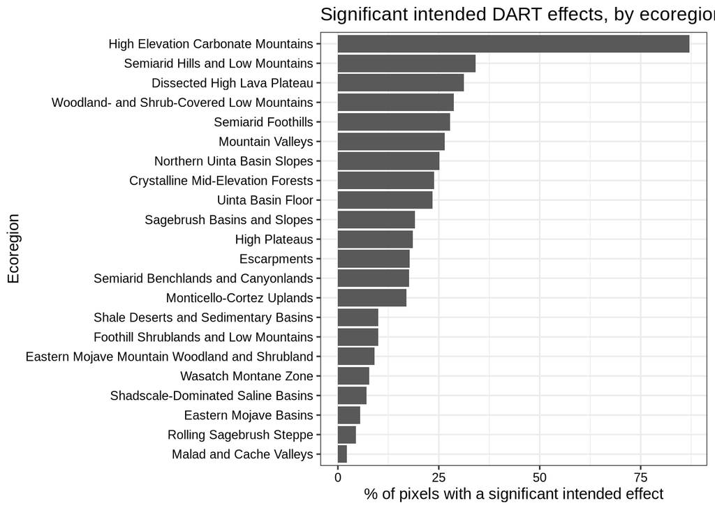

**Table and figure.** As above, grouped by level-IV ecoregion (`'us_l4name'`). X axis: % of that ecoregion’s pixels with a significant *intended* (positive) effect. Y axis: ecoregion, ordered by that percentage. Single grey fill, no facets. Range across the 22 ecoregions: 2.27% to 87.13%.

#### Significant DART effects, through time

The same effects along the time axis and against the covariates that interact with it: how often a significant effect occurred in each year since treatment, how large those effects were and when they peaked, and how the per-polygon peak years distribute across treatments and ecoregions. Read the two halves as separate questions - a year can carry a high significance rate with small effects, or the reverse.

##### How does time since treatment affect significance?

This section attempts to answer two questions:

1. How *often* does a significant effect show up in a given year? The stacked-direction figure immediately below.
2. How *large* are those effects? The mean-effect table and figure further down. A year can have a handful of significant pixels that each moved a long way, or many pixels that each moved a little, and those are different results.

No weighting is used anywhere in this section. The mean effect per year is a plain arithmetic mean of `effect` over the significant pixels in that year, split by direction of effect, so the reported peak is the year whose significant pixels actually moved furthest rather than a significance-weighted compromise across the whole time series. Some weighting methods were checked and did not improve the results - see `weight_testing_summary.Rmd` for that analysis.

Everything in this section is drawn on the **truncated** series: for this objective no year fell below the 10-significant-pixel threshold, so the full record to year 33 is used. This is what stops a peak year being reported from the part of the record where almost nothing was significant; it also means the x axis here can end earlier than another objective’s, so the two are not read off the same range.

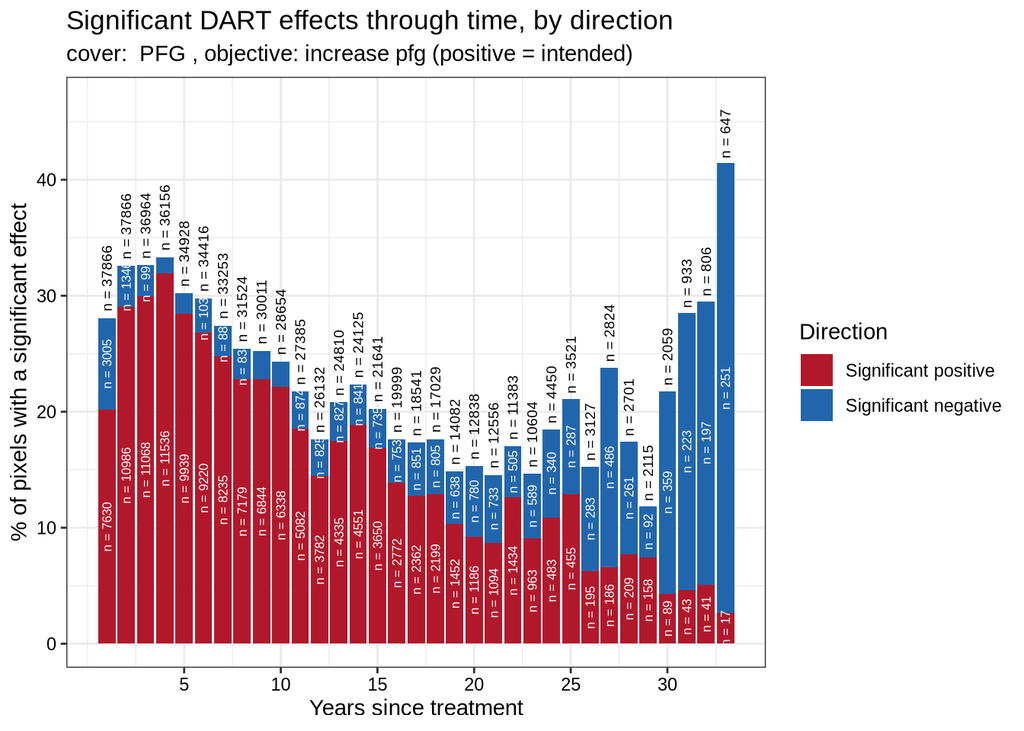

**Figure.** X axis: years since treatment, one bar per year, labelled every 5 years. Y axis: the percentage of that year’s pixels with a significant DART effect - the full height of a bar is the year’s overall % significant, and it is a percentage of all pixels observed in that year, not of the significant ones. Fill: the direction of the significant effect, splitting each bar into a blue *significant negative* component and a red *significant positive* component; the intended direction for this objective (positive) is the segment drawn against the axis, with the unintended direction stacked above it. Fill colours mean the same thing in every direction figure in this report. There are no facets or other groupings.

Two different sample sizes are labelled on each bar, and they are **not** meant to sum to each other:

- The rotated label sitting *above* each bar is that year’s **group total** - every pixel observed in that year, significant or not. It says how much data is behind the bar, and it is the denominator of the percentage on the Y axis.
- The white label *inside* each stacked segment is the number of pixels that were significant **and** in that segment’s direction. These two are the sample sizes behind the two segment heights themselves.

So the two segment labels add up to the number of *significant* pixels in that year, which is generally far smaller than the group total above the bar, because most pixels in a year are not significant. Reading down a tall bar with a small group total is therefore a different situation from a short bar with a large one, which is exactly why both numbers are drawn. Segments too short to hold their label legibly are left unlabelled to avoid white text spilling onto the panel background.

- Treatment was **most** effective (highest % significant pixels) at year 33 (41.4% significant).
- Treatment was **least** effective (lowest % significant pixels) at year 29 (11.8% significant).

##### How large were the significant effects in each year?

The figure below switches from counting significant pixels to measuring them: among significant pixels only, what was the mean DART effect in each year since treatment, and in which year was that mean largest? Positive and negative effects are summarized separately throughout.

| Direction | Peak Year | Mean Effect at Peak | SE | Significant Pixels at Peak | Last Year Observed | Peak Censored? |
| --- | --- | --- | --- | --- | --- | --- |
| negative | 21 | -10.5936 | 0.1468 | 733 | 33 | FALSE |
| positive | 33 | 23.4308 | 2.3622 | 17 | 33 | TRUE |

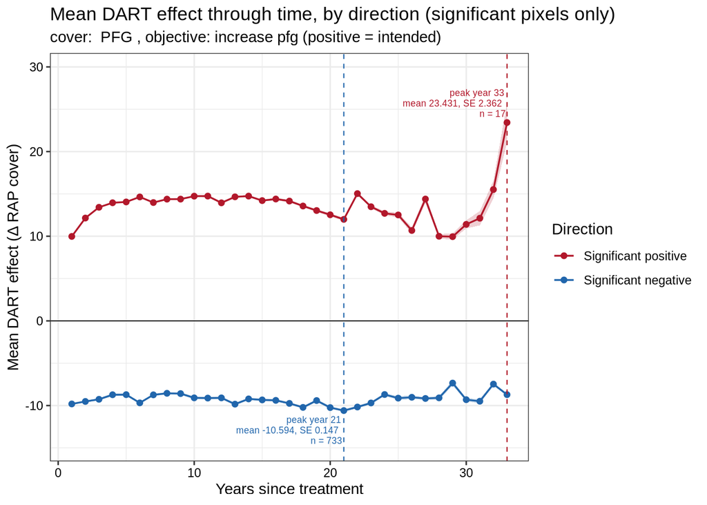

**Table.** One row per direction of effect: the year in which the mean effect over significant pixels was largest in magnitude, that mean, its SE, the number of significant pixels behind it, the last year observed for that direction, and whether the peak is censored (lands on that last year).

**Figure.** X axis: years since treatment. Y axis: the mean DART effect (Δ RAP cover) among *significant pixels only* in that year, computed separately for each direction - so the two series sit either side of the zero line by construction and are never averaged into a single number. Colour: direction of the effect (red = significant positive, blue = significant negative), using the same colours as the stacked figure above. The shaded band around each line is that year × direction mean ± 1 SE: it is sampling uncertainty in the *mean* effect, not the spread of individual pixel effects, so it narrows mainly where a year has many significant pixels. A year × direction cell backed by a single significant pixel has no SE and is drawn as a bare point, keeping the line through it unbroken. Dashed vertical lines mark each direction’s peak year from the table above, labelled with the mean effect at the peak, its SE, and the number of significant pixels behind it. Non-significant pixels are excluded outright rather than entered as zeros, and no weighting is applied anywhere. There are no facets or other groupings.

- Significant **negative** effects were largest at year 21 (mean effect -10.5936, SE 0.1468, n = 733 significant pixels).
- Significant **positive** effects were largest at year 33 (mean effect 23.4308, SE 2.3622, n = 17 significant pixels), which is the last year observed for that direction - the effect may still have been growing past the end of the record.

Note that the year with the largest mean effect need not be the year with the most significant pixels: the two questions can peak at different times, and a peak that lands on the last observed year is flagged as censored above for the same reason as in the by-polygon table further down.

| Objective | Cover | Year Bin | Total Pixels | Mean % Significant | Mean % Significant Positive | Mean % Significant Negative |
| --- | --- | --- | --- | --- | --- | --- |
| increase_pfg | PFG | 1-5 | 183780 | 31.35 | 27.84 | 3.52 |
| increase_pfg | PFG | 6-10 | 157858 | 26.57 | 23.96 | 2.62 |
| increase_pfg | PFG | 11-15 | 124093 | 20.55 | 17.25 | 3.31 |
| increase_pfg | PFG | 16+ | 140215 | 16.95 | 10.94 | 6.01 |

**Table.** The same significance rates as the year-by-year figure, collapsed into 1-5, 6-10, 11-15 and 16+ years since treatment. One row per bin; percentages are of all pixels in that bin, and the two directional columns sum to the overall column up to rounding.

| Treatment | N Polygons | Mean Year of Peak Sig. | SD | Min | Max | % Censored (peak at last obs. year) |
| --- | --- | --- | --- | --- | --- | --- |
| prescribed burn | 13 | 9.69 | 7.72 | 1 | 23 | 0.0 |
| prescribed burn;seeding | 6 | 4.33 | 6.74 | 1 | 18 | 0.0 |
| prescribed burn;seeding;soil disturbance;vegetation removal | 3 | 1.67 | 1.15 | 1 | 3 | 0.0 |
| prescribed burn;soil disturbance | 1 | 2.00 |  | 2 | 2 | 0.0 |
| prescribed burn;vegetation removal | 4 | 4.50 | 3.11 | 1 | 8 | 0.0 |
| seeding | 135 | 4.76 | 5.57 | 1 | 28 | 3.7 |
| seeding;soil disturbance | 165 | 4.57 | 4.26 | 1 | 27 | 8.5 |
| seeding;soil disturbance;vegetation removal | 42 | 3.60 | 2.86 | 1 | 15 | 4.8 |
| seeding;vegetation removal | 89 | 2.96 | 2.62 | 1 | 16 | 5.6 |
| soil disturbance | 19 | 4.16 | 3.08 | 1 | 10 | 5.3 |
| soil disturbance;vegetation removal | 8 | 3.25 | 3.41 | 1 | 10 | 0.0 |
| vegetation removal | 54 | 4.17 | 3.46 | 1 | 17 | 7.4 |

| Ecoregion | N Polygons | Mean Year of Peak Sig. | SD | Min | Max | % Censored (peak at last obs. year) |
| --- | --- | --- | --- | --- | --- | --- |
| Crystalline Mid-Elevation Forests | 2 | 4.00 | 2.83 | 2 | 6 | 0.0 |
| Dissected High Lava Plateau | 12 | 3.50 | 2.94 | 1 | 11 | 8.3 |
| Eastern Mojave Basins | 1 | 17.00 |  | 17 | 17 | 0.0 |
| Eastern Mojave Mountain Woodland and Shrubland | 4 | 1.75 | 1.50 | 1 | 4 | 0.0 |
| Escarpments | 19 | 4.05 | 5.01 | 1 | 23 | 0.0 |
| Foothill Shrublands and Low Mountains | 7 | 2.86 | 2.34 | 1 | 7 | 0.0 |
| High Elevation Carbonate Mountains | 1 | 7.00 |  | 7 | 7 | 0.0 |
| High Plateaus | 2 | 5.00 | 2.83 | 3 | 7 | 0.0 |
| Malad and Cache Valleys | 2 | 4.50 | 0.71 | 4 | 5 | 0.0 |
| Monticello-Cortez Uplands | 7 | 3.00 | 2.83 | 1 | 9 | 0.0 |
| Mountain Valleys | 23 | 3.00 | 2.70 | 1 | 10 | 4.3 |
| Northern Uinta Basin Slopes | 5 | 3.60 | 2.30 | 1 | 7 | 20.0 |
| Rolling Sagebrush Steppe | 3 | 2.67 | 1.53 | 1 | 4 | 0.0 |
| Sagebrush Basins and Slopes | 109 | 4.97 | 5.44 | 1 | 28 | 4.6 |
| Semiarid Benchlands and Canyonlands | 131 | 4.17 | 4.49 | 1 | 27 | 3.1 |
| Semiarid Foothills | 72 | 3.54 | 2.47 | 1 | 10 | 5.6 |
| Semiarid Hills and Low Mountains | 8 | 2.75 | 1.91 | 1 | 7 | 0.0 |
| Shadscale-Dominated Saline Basins | 17 | 6.88 | 7.36 | 1 | 27 | 11.8 |
| Shale Deserts and Sedimentary Basins | 4 | 6.50 | 4.20 | 1 | 11 | 0.0 |
| Uinta Basin Floor | 3 | 5.33 | 0.58 | 5 | 6 | 0.0 |
| Wasatch Montane Zone | 6 | 5.67 | 3.56 | 1 | 10 | 33.3 |
| Woodland- and Shrub-Covered Low Mountains | 101 | 4.43 | 4.39 | 1 | 27 | 10.9 |

**Tables.** Each polygon is reduced to the single year in which its own % significant pixels was highest (“peak significance year”); those per-polygon peak years are then summarized across polygons, by treatment in the first table and by ecoregion in the second. Columns: number of polygons behind the row, mean / SD / min / max of the peak year, and the percentage of polygons whose peak fell on the last year they were observed. A polygon’s peak year is flagged as “censored” in those cases, because we can’t rule out that significance was still rising beyond the end of the available time series. Note that “last year observed” now means the last year *retained* after the late-year truncation described above, so where a series was truncated the censoring flag is partly an artefact of the threshold rather than of the record itself - it marks the end of the analysable series, not necessarily the end of the data. What that censoring implies is taken up under *Interpretation* at the end of the report.

#### Overall results and interpretation

##### Summary statistics

What the three sample-size filters cost this objective x cover response, in one row - the same quantities reported in prose under *Results after dropping* above, gathered here so that this subsection stands on its own. The identical row appears in the cross-objective filtering log in `2_make_DART_results.Rmd`, where it can be read against the other objectives.

| Objective | Cover | Min Pixels per Tx x Eco | # Tx x Eco Excluded | # Tx Depopulated | # Eco Depopulated | Min Pixels per Year | Year Truncated At | # Years Dropped | % Pixels Lost | # Tx Absent | # Eco Absent |
| --- | --- | --- | --- | --- | --- | --- | --- | --- | --- | --- | --- |
| increase_pfg | PFG | 300 | 27 | 0 | 0 | 10 | NA | 0 | 0.48 | 1 | 6 |

**Table.** One row for this objective x cover response. `% Pixels Lost` is the combined cost of all three filters, not the cell filter alone. `# Tx Absent` / `# Eco Absent` count levels missing from the post-filter data for any reason, which is a different quantity from the two depopulated columns: a level that only ever appeared in sparse cells disappears without the depopulation filter being involved.

Post-filter, this objective x cover response retains 605946 pixels across 12 treatment level(s) and 22 ecoregion level(s), the smallest surviving totals being 1035 pixels for a treatment and 484 for an ecoregion, against a per-cell threshold of 300.

### cover: SHR , objective: increase shr

#### Sample sizes and scope

How much data backs this objective x cover response, how much of it the three sample-size filters removed, and how much of it is shared with other objectives. Everything here is descriptive: no treatment effect is reported in this subsection. Pixel counts are shown per treatment x ecoregion cell, which is the unit the first filter works on, and then again per treatment and per ecoregion *after* filtering - the pre-filter totals by treatment and by ecoregion were dropped as unhelpful, since nothing downstream is built on them.

##### Pixel counts for each treatment × ecoregion combination (`'tx_coarse'` x `'us_l4name'`)

Each level of (treatment x ecoregion) is filtered here for low sample size (300 pixels).

|  | Arid Canyonlands | Crystalline Mid-Elevation Forests | Dissected High Lava Plateau | Eastern Mojave Basins | Eastern Mojave Low Ranges and Arid Footslopes | Eastern Mojave Mountain Woodland and Shrubland | Escarpments | Foothill Shrublands and Low Mountains | High Elevation Carbonate Mountains | High Elevation Forests and Shrublands | Malad and Cache Valleys | Mid-Elevation Uinta Mountains | Monticello-Cortez Uplands | Mountain Valleys | Northern Uinta Basin Slopes | Rolling Sagebrush Steppe | Sagebrush Basins and Slopes | Semiarid Benchlands and Canyonlands | Semiarid Foothills | Semiarid Hills and Low Mountains | Shadscale-Dominated Saline Basins | Shale Deserts and Sedimentary Basins | Sub-Irrigated High Valleys | Uinta Basin Floor | Wasatch Montane Zone | Wetlands | Woodland- and Shrub-Covered Low Mountains |
| --- | --- | --- | --- | --- | --- | --- | --- | --- | --- | --- | --- | --- | --- | --- | --- | --- | --- | --- | --- | --- | --- | --- | --- | --- | --- | --- | --- |
| prescribed burn | 0 | 0 | 0 | 0 | 0 | 0 | 3759 | 0 | 0 | 0 | 0 | 0 | 0 | 0 | 0 | 0 | 0 | 22790 | 0 | 0 | 0 | 0 | 0 | 0 | 0 | 0 | 0 |
| prescribed burn;seeding | 0 | 0 | 0 | 0 | 0 | 0 | 0 | 0 | 0 | 0 | 0 | 0 | 0 | 0 | 0 | 0 | 0 | 0 | 0 | 0 | 0 | 0 | 0 | 0 | 30 | 0 | 0 |
| prescribed burn;seeding;soil disturbance;vegetation removal | 0 | 0 | 0 | 0 | 0 | 0 | 0 | 0 | 0 | 0 | 0 | 0 | 0 | 0 | 0 | 0 | 328 | 731 | 0 | 0 | 0 | 0 | 0 | 0 | 0 | 0 | 0 |
| prescribed burn;soil disturbance | 0 | 0 | 0 | 0 | 0 | 0 | 0 | 0 | 0 | 0 | 0 | 0 | 0 | 0 | 0 | 0 | 0 | 0 | 2205 | 0 | 0 | 0 | 0 | 0 | 0 | 0 | 0 |
| prescribed burn;soil disturbance;vegetation removal | 0 | 0 | 0 | 0 | 0 | 0 | 0 | 0 | 0 | 0 | 0 | 0 | 0 | 0 | 0 | 0 | 3780 | 0 | 0 | 0 | 0 | 0 | 0 | 0 | 0 | 0 | 0 |
| prescribed burn;vegetation removal | 0 | 0 | 0 | 0 | 0 | 0 | 0 | 0 | 0 | 0 | 0 | 0 | 0 | 0 | 0 | 0 | 0 | 0 | 475 | 0 | 0 | 0 | 0 | 0 | 0 | 0 | 1040 |
| seeding | 0 | 451 | 462 | 576 | 0 | 3179 | 258 | 28566 | 1974 | 0 | 0 | 0 | 723 | 567 | 2053 | 40 | 7485 | 15994 | 6086 | 1936 | 875 | 351 | 295 | 0 | 0 | 0 | 10723 |
| seeding;soil disturbance | 168 | 0 | 3973 | 0 | 0 | 0 | 0 | 2496 | 0 | 24 | 180 | 0 | 0 | 251 | 638 | 0 | 18590 | 10542 | 8369 | 1290 | 13446 | 0 | 0 | 0 | 1044 | 0 | 17400 |
| seeding;soil disturbance;vegetation removal | 0 | 0 | 0 | 0 | 0 | 0 | 612 | 0 | 0 | 0 | 0 | 0 | 0 | 487 | 54 | 0 | 1429 | 4351 | 2215 | 0 | 0 | 0 | 0 | 36 | 0 | 65 | 4583 |
| seeding;vegetation removal | 0 | 0 | 3140 | 0 | 0 | 0 | 1555 | 252 | 0 | 0 | 81 | 84 | 0 | 267 | 0 | 313 | 2406 | 11600 | 3727 | 2618 | 384 | 3978 | 0 | 132 | 0 | 8 | 6181 |
| soil disturbance | 0 | 0 | 0 | 0 | 65 | 0 | 0 | 0 | 0 | 0 | 0 | 0 | 0 | 0 | 0 | 0 | 288 | 896 | 1204 | 0 | 27 | 0 | 0 | 0 | 0 | 0 | 0 |
| soil disturbance;vegetation removal | 0 | 0 | 0 | 0 | 0 | 0 | 0 | 1968 | 0 | 0 | 0 | 0 | 308 | 0 | 0 | 0 | 192 | 1044 | 2386 | 0 | 0 | 0 | 0 | 0 | 0 | 6 | 522 |
| vegetation removal | 0 | 144 | 0 | 0 | 0 | 0 | 280 | 0 | 0 | 0 | 188 | 14 | 0 | 0 | 1692 | 0 | 9676 | 9804 | 5435 | 0 | 0 | 42 | 0 | 0 | 3209 | 0 | 3260 |

|  | Arid Canyonlands | Crystalline Mid-Elevation Forests | Eastern Mojave Low Ranges and Arid Footslopes | Escarpments | Foothill Shrublands and Low Mountains | High Elevation Forests and Shrublands | Malad and Cache Valleys | Mid-Elevation Uinta Mountains | Mountain Valleys | Northern Uinta Basin Slopes | Rolling Sagebrush Steppe | Sagebrush Basins and Slopes | Shadscale-Dominated Saline Basins | Shale Deserts and Sedimentary Basins | Sub-Irrigated High Valleys | Uinta Basin Floor | Wasatch Montane Zone | Wetlands |
| --- | --- | --- | --- | --- | --- | --- | --- | --- | --- | --- | --- | --- | --- | --- | --- | --- | --- | --- |
| prescribed burn;seeding |  |  |  |  |  |  |  |  |  |  |  |  |  |  |  |  | 30 |  |
| seeding |  |  |  | 258 |  |  |  |  |  |  | 40 |  |  |  | 295 |  |  |  |
| seeding;soil disturbance | 168 |  |  |  |  | 24 | 180 |  | 251 |  |  |  |  |  |  |  |  |  |
| seeding;soil disturbance;vegetation removal |  |  |  |  |  |  |  |  |  | 54 |  |  |  |  |  | 36 |  | 65 |
| seeding;vegetation removal |  |  |  |  | 252 |  | 81 | 84 | 267 |  |  |  |  |  |  | 132 |  | 8 |
| soil disturbance |  |  | 65 |  |  |  |  |  |  |  |  | 288 | 27 |  |  |  |  |  |
| soil disturbance;vegetation removal |  |  |  |  |  |  |  |  |  |  |  | 192 |  |  |  |  |  | 6 |
| vegetation removal |  | 144 |  | 280 |  |  | 188 | 14 |  |  |  |  |  | 42 |  |  |  |  |

**Table.** The first table is the full pixel count for every treatment (rows) x ecoregion (columns) combination; the second keeps only the cells that are non-zero but below the 300-pixel threshold, i.e. the combinations that are present but too sparse to analyse. Empty cells in the second table are combinations that are either absent or above the threshold.

| Treatment | Ecoregion |
| --- | --- |
| seeding;soil disturbance | Arid Canyonlands |
| vegetation removal | Crystalline Mid-Elevation Forests |
| soil disturbance | Eastern Mojave Low Ranges and Arid Footslopes |
| seeding | Escarpments |
| vegetation removal | Escarpments |
| seeding;vegetation removal | Foothill Shrublands and Low Mountains |
| seeding;soil disturbance | High Elevation Forests and Shrublands |
| seeding;soil disturbance | Malad and Cache Valleys |
| seeding;vegetation removal | Malad and Cache Valleys |
| vegetation removal | Malad and Cache Valleys |
| seeding;vegetation removal | Mid-Elevation Uinta Mountains |
| vegetation removal | Mid-Elevation Uinta Mountains |
| seeding;soil disturbance | Mountain Valleys |
| seeding;vegetation removal | Mountain Valleys |
| seeding;soil disturbance;vegetation removal | Northern Uinta Basin Slopes |
| seeding | Rolling Sagebrush Steppe |
| soil disturbance | Sagebrush Basins and Slopes |
| soil disturbance;vegetation removal | Sagebrush Basins and Slopes |
| soil disturbance | Shadscale-Dominated Saline Basins |
| vegetation removal | Shale Deserts and Sedimentary Basins |
| seeding | Sub-Irrigated High Valleys |
| seeding;soil disturbance;vegetation removal | Uinta Basin Floor |
| seeding;vegetation removal | Uinta Basin Floor |
| prescribed burn;seeding | Wasatch Montane Zone |
| seeding;soil disturbance;vegetation removal | Wetlands |
| seeding;vegetation removal | Wetlands |
| soil disturbance;vegetation removal | Wetlands |

**Table.** 27 treatment x ecoregion combinations fall below the 300-pixel threshold, representing 1.20% of the total sample size for this objective x cover response. Each row is one combination that will be dropped below.

**Are these sparse combinations especially significant (or non-significant)?**

| Treatment | Ecoregion | Significant Pixels | Total Pixels | % Significant Pixels |
| --- | --- | --- | --- | --- |
| prescribed burn;seeding | Wasatch Montane Zone | 6 | 30 | 20.00 |
| seeding | Escarpments | 31 | 258 | 12.02 |
| seeding | Rolling Sagebrush Steppe | 0 | 40 | 0.00 |
| seeding | Sub-Irrigated High Valleys | 85 | 295 | 28.81 |
| seeding;soil disturbance | Arid Canyonlands | 61 | 168 | 36.31 |
| seeding;soil disturbance | High Elevation Forests and Shrublands | 9 | 24 | 37.50 |
| seeding;soil disturbance | Malad and Cache Valleys | 32 | 180 | 17.78 |
| seeding;soil disturbance | Mountain Valleys | 33 | 251 | 13.15 |
| seeding;soil disturbance;vegetation removal | Northern Uinta Basin Slopes | 2 | 54 | 3.70 |
| seeding;soil disturbance;vegetation removal | Uinta Basin Floor | 32 | 36 | 88.89 |
| seeding;soil disturbance;vegetation removal | Wetlands | 10 | 65 | 15.38 |
| seeding;vegetation removal | Foothill Shrublands and Low Mountains | 223 | 252 | 88.49 |
| seeding;vegetation removal | Malad and Cache Valleys | 13 | 81 | 16.05 |
| seeding;vegetation removal | Mid-Elevation Uinta Mountains | 23 | 84 | 27.38 |
| seeding;vegetation removal | Mountain Valleys | 32 | 267 | 11.99 |
| seeding;vegetation removal | Uinta Basin Floor | 0 | 132 | 0.00 |
| seeding;vegetation removal | Wetlands | 2 | 8 | 25.00 |
| soil disturbance | Eastern Mojave Low Ranges and Arid Footslopes | 25 | 65 | 38.46 |
| soil disturbance | Sagebrush Basins and Slopes | 113 | 288 | 39.24 |
| soil disturbance | Shadscale-Dominated Saline Basins | 0 | 27 | 0.00 |
| soil disturbance;vegetation removal | Sagebrush Basins and Slopes | 0 | 192 | 0.00 |
| soil disturbance;vegetation removal | Wetlands | 0 | 6 | 0.00 |
| vegetation removal | Crystalline Mid-Elevation Forests | 36 | 144 | 25.00 |
| vegetation removal | Escarpments | 112 | 280 | 40.00 |
| vegetation removal | Malad and Cache Valleys | 39 | 188 | 20.74 |
| vegetation removal | Mid-Elevation Uinta Mountains | 3 | 14 | 21.43 |
| vegetation removal | Shale Deserts and Sedimentary Basins | 10 | 42 | 23.81 |

**Table.** Significance rate within the sparse combinations only: one row per dropped treatment x ecoregion combination, giving its significant pixel count, its total pixel count, and the resulting percentage. Compare against the overall rate reported further down to see whether the dropped cells were unusual.

##### Results after dropping (treatment x ecoregion)

The pixel cutoff for each (treatment × ecoregion) combination was 300.

Three filters have now been applied to this objective x cover response, in this order, and the percentage below is the combined cost of all three:

1. **Sparse (treatment x ecoregion) cells** - the 27 combinations listed above, below 300 pixels each.
2. **Depopulated treatment or ecoregion levels** - on, at the same 300-pixel threshold: 0 treatment and 0 ecoregion level(s) removed. This catches a level thinned across many surviving cells, which the cell filter cannot see.
3. **Late-year truncation** - no year fell below 10 significant pixels, so the series was not truncated.

Total data lost across all three: **1.20%**. Treatment levels absent from the post-filter data: `prescribed burn;seeding`. Ecoregion levels absent: `Eastern Mojave Low Ranges and Arid Footslopes`, `High Elevation Forests and Shrublands`, `Malad and Cache Valleys`, `Sub-Irrigated High Valleys`, `Mid-Elevation Uinta Mountains`, `Wetlands`, `Uinta Basin Floor`, `Arid Canyonlands`. (These are levels gone for *any* reason - a level that only ever appeared in sparse cells disappears without the depopulation filter being involved.)

The post-filter totals below are the check that the three filters together have not left some treatment or ecoregion analysable in name only.

| Treatment | Pixel Count (post-filter) |
| --- | --- |
| prescribed burn | 26549 |
| prescribed burn;seeding;soil disturbance;vegetation removal | 1059 |
| prescribed burn;soil disturbance | 2205 |
| prescribed burn;soil disturbance;vegetation removal | 3780 |
| prescribed burn;vegetation removal | 1515 |
| seeding | 82001 |
| seeding;soil disturbance | 77788 |
| seeding;soil disturbance;vegetation removal | 13677 |
| seeding;vegetation removal | 35902 |
| soil disturbance | 2100 |
| soil disturbance;vegetation removal | 6228 |
| vegetation removal | 33076 |

| Ecoregion | Pixel Count (post-filter) |
| --- | --- |
| Crystalline Mid-Elevation Forests | 451 |
| Dissected High Lava Plateau | 7575 |
| Eastern Mojave Basins | 576 |
| Eastern Mojave Mountain Woodland and Shrubland | 3179 |
| Escarpments | 5926 |
| Foothill Shrublands and Low Mountains | 33030 |
| High Elevation Carbonate Mountains | 1974 |
| Monticello-Cortez Uplands | 1031 |
| Mountain Valleys | 1054 |
| Northern Uinta Basin Slopes | 4383 |
| Rolling Sagebrush Steppe | 313 |
| Sagebrush Basins and Slopes | 43694 |
| Semiarid Benchlands and Canyonlands | 77752 |
| Semiarid Foothills | 32102 |
| Semiarid Hills and Low Mountains | 5844 |
| Shadscale-Dominated Saline Basins | 14705 |
| Shale Deserts and Sedimentary Basins | 4329 |
| Wasatch Montane Zone | 4253 |
| Woodland- and Shrub-Covered Low Mountains | 43709 |

**Tables.** Post-filter pixel totals, by treatment and by ecoregion, after the sparse combinations above were dropped. The smallest surviving treatment total is 1059 pixels and the smallest surviving ecoregion total is 313 pixels, against a combination-level threshold of 300.

##### How often does this objective overlap with other objectives?

| Objective | Cover | Co-occurring Objective | Pixel Count | % of Total Pixels |
| --- | --- | --- | --- | --- |
| increase_shr | SHR | none | 2525 | 0.88 |
| increase_shr | SHR | increase_pfg | 254531 | 89.03 |
| increase_shr | SHR | decrease_tre | 134904 | 47.19 |
| increase_shr | SHR | decrease_afg | 47256 | 16.53 |
| increase_shr | SHR | increase_afg | 17087 | 5.98 |
| increase_shr | SHR | null_afg | 14012 | 4.90 |
| increase_shr | SHR | increase_tre | 2317 | 0.81 |

**Table.** Among pixels assigned to increase_shr, how often each *other* objective was also assigned to that same pixel. The first row (`none`) is the pixels that carried no other objective. Percentages are shares of this objective’s own (post-filter) pixel total, so they sum to more than 100% wherever pixels carry more than two objectives.